# SP500 Relative-Momentum Strategy

From a momentum feature to an implementable long/short portfolio

Author

Mike Aguilar | https://www.linkedin.com/in/mike-aguilar-econ/

# Background

## Goal

We take a 12-2 momentum feature on S&P 500 constituents and walk it, one layer at a time, into a single implementable relative-momentum 120/20 long/short portfolio, which we then evaluate against IVV.

The emphasis is the *architecture* of that transformation; i.e. how a measured feature becomes a signal, a position, a set of strategy weights, and finally portfolio capital, and the *attribution* of the result. Along the way we also evaluate the quartile signal directly, both on a single holdout and walk-forward across the holdout window so the reader can gauge whether the traded signal carries any predictive power before it is turned into a portfolio. Given the short frozen sample, that evaluation is illustrative rather than a definitive verdict on momentum.

The layers we keep distinct throughout are:

$$\text{feature} \;\longrightarrow\; \text{signal} \;\longrightarrow\; \text{position} \;\longrightarrow\; \text{raw strategy weights} \;\longrightarrow\; \text{scaled strategy weights} \;\longrightarrow\; \text{portfolio weights}$$

Key Assumptions:

- Signal: a cross-sectional quartile rule: long the top quartile, short the bottom quartile, neutral in between. There is no absolute threshold.
- Strategy: size positions based on relative momentum: $a_{i,t} = \lvert mom_{i,t} - \tilde{mom}_t \rvert$
- Portfolio: 120/20 long short
- A signal formed on a month’s last trading day becomes effective on the first trading day of the next month and cannot earn the formation-date return.
- Target weights are held constant through the evaluation month (frictionless daily rebalancing).

## Architecture

The document follows the order we work through in class.

- **Housekeeping & settings** — load packages and the supporting functions in `R/`, then define one visible `settings` object (formation and evaluation periods, benchmark, sleeve budgets, labels, penalties).
- **Data** — load the frozen inputs, then clean and engineer:
  - S&P 500 constituents are frozen by `data-preparation/01-build-static-universe.R` into `data/sp500-static-universe.csv`.
  - Daily adjusted closing prices for the constituents and the index (IVV) are frozen by `data-preparation/02-build-frozen-price-data.R` into `data/daily-adjusted-prices.rds`, and aggregated to month-end into `data/monthly-adjusted-prices.rds`.
  - Engineering builds monthly simple returns and 12-2 momentum.
- **EDA** — formation-time views (momentum distributions with quartile cutoffs, quartile signal counts, IVV context) plus distributional comparisons of the holdout return and formation momentum cross-sections, and the momentum → next-month-return relationship.
- **Single hold out** — form the strategy on the **May 2026** month-end and evaluate over **June 2026**, showing *every* transformation inline, and evaluate the June quartile signal’s efficacy (raw and benchmark-relative).
- **Multiple hold out** — abstract the demonstrated construction into one small local function and roll the formation month forward (May→June, June→July, July→August), chaining the results into one continuous portfolio history, then evaluate the signal walk-forward across the three holdouts.

## Notation

We follow the portfolio-creation pipeline from the lecture notes:

$$X_{i,t},\, Z_t \;\longrightarrow\; s_{i,t} \;\longrightarrow\; s^{pos}_{i,t} \;\longrightarrow\; w^{raw}_{i,t} \;\longrightarrow\; w^{scaled}_{i,t} \;\longrightarrow\; w^{p}_{i,t}$$

| Symbol | Meaning | In this exercise |
| --- | --- | --- |
| $X_{i,t},\, Z_t$ | Asset-specific and general features | 12-2 momentum $mom_{i,t}$ (IVV momentum as context) |
| $s_{i,t}$ | Signal $\in \{-1, 0, +1\}$ | $+1$ if $mom_{i,t} > q_{0.75,t}$; $-1$ if $mom_{i,t} < q_{0.25,t}$; else $0$ |
| $s^{pos}_{i,t}$ | Position after timing / exit rules | $s^{pos}_{i,t} = s_{i,t}$ (no extra position rule here) |
| $w^{raw}_{i,t}$ | Signed pre-normalized position size | $w^{raw}_{i,t} = s^{pos}_{i,t}\,a_{i,t}$ — direction **and** relative size |
| $w^{scaled}_{i,t}$ | Weights scaled within each sleeve | long sleeve sums to $+1$, short sleeve to $-1$ |
| $w^{p}_{i,t}$ | Final portfolio weights (capital + leverage) | 120/20 budgets applied: $B_L w^{scaled}$ (long), $B_S w^{scaled}$ (short) |

Other recurring symbols:

| Symbol | Meaning |
| --- | --- |
| $q_{0.25,t},\ q_{0.75,t}$ | Cross-sectional 25th and 75th momentum percentiles at $t$ (R `quantile`, `type = 7`) |
| $\tilde{mom}_t$ | Cross-sectional median momentum at $t$ |
| $a_{i,t} = \lvert mom_{i,t} - \tilde{mom}_t \rvert$ | Relative momentum strength |
| $G^{+}_t,\ G^{-}_t$ | Sum of positive raw weights; sum of $\lvert$negative raw weights$\rvert$ |
| $B_L,\ B_S$ | Long and short budgets ($1.20$, $0.20$) |
| $N^{+}_{t},\ N^{-}_{t}$ | Number of long and short selections at $t$ |
| $R_{i,d}$ | Daily simple return of asset $i$ on day $d$ |
| $R_{p,d} = \sum_i w^{p}_{i,t}\, R_{i,d}$ | Daily portfolio return under constant target weights |

# Housekeeping

Task: Load packages, source the supporting functions in `R/`, and define shared helpers (colors, `pct()`, `gt_compact()`, `attr_tab()`, etc..).

```r
suppressPackageStartupMessages(library(here))

# Course-wide packages and helpers (tidyverse, lubridate, gt, scales, plotly, ...).
source(here("Supporting", "ProjectSetup.R"))

# ProjectSetup.R attaches packages after the tidyverse (e.g. mclust::count,
# rugarch::reduce) that mask core verbs. Re-point the affected verbs to dplyr,
# mirroring the `select <- dplyr::select` fix ProjectSetup.R already applies.
count  <- dplyr::count
filter <- dplyr::filter

base <- here("Topics", "SP500Momentum")
for (f in c("portfolio_engine.R", "performance_metrics.R", "attribution.R", "validation.R")) {
  source(file.path(base, "R", f))
}

# Signal-evaluation engines (single- and multiple-holdout) used by the
# "Signal Efficacy" sections; they consume a generic +1/0/-1 signal_position.
source(here("Supporting", "Signal_Evaluation_SingleHoldOut.R"))
source(here("Supporting", "Signal_Evaluation_MultipleHoldOut.R"))

theme_set(theme_minimal(base_size = 12))

bucket_colors <- c(
  "Top Negative"   = "#a50f15",
  "Other Negative" = "#fcae91",
  "Other Positive" = "#a1d99b",
  "Top Positive"   = "#006d2c"
)

strategy_color  <- "#2166ac"
benchmark_color <- "black"

pct <- function(x, acc = 0.1) percent(x, accuracy = acc)
ppts <- function(x) round(x * 100, 1) |> format(nsmall = 1, trim = TRUE) |> paste0(" ppts")

gt_compact <- function(df, title = NULL, subtitle = NULL) {
  g <- gt(df)
  if (!is.null(title)) g <- tab_header(g, title = title, subtitle = subtitle)
  g |>
    sub_missing(missing_text = "—") |>
    cols_align(align = "center") |>
    opt_row_striping()
}

# Security attribution chart + sleeve table for one period; used in the tabset.
# Reads the continuous `contrib` / `port` objects built in the rolling section.
attr_tab <- function(period, label) {
  sec <- security_attribution(contrib, port, period)
  p <- contributor_buckets(sec) |>
    mutate(bucket = factor(bucket, levels = names(bucket_colors))) |>
    ggplot(aes(x = contribution, y = reorder(ticker, contribution), fill = bucket)) +
    geom_col() +
    scale_fill_manual(values = bucket_colors) +
    scale_x_continuous(labels = percent_format(accuracy = 0.1)) +
    labs(x = "Linked contribution", y = NULL, fill = NULL,
         title = paste0("Security attribution — 120/20 Strategy (", label, ")")) +
    theme(legend.position = "bottom")
  print(p)
  sleeve_attribution(sec) |>
    transmute(Sleeve = sleeve, Contribution = ppts(contribution)) |>
    gt_compact()
}
```

## Settings

Task: Establish settings for the long and short budgets, benchmark ticker, and other items

```r
settings <- list(
  B_L           = 1.20,   # long budget
  B_S           = 0.20,   # short budget
  benchmark     = "IVV",
  annualization = 252,
  min_risk_obs  = 15,     # below this, risk stats are illustrative only
  lambda        = 0.5,    # turnover penalty
  labels = c(
    strategy  = "Relative-Momentum 120/20",
    benchmark = "IVV Benchmark"
  )
)
```

Q: What do the long budget 1.20 and short budget 0.20 mean? If we changed those, would they impact i) signal, ii) strategy, iii) portfolio?

A: They are the sleeve capital budgets applied in the portfolio layer. For every $1 of capital, the strategy holds $1.20 long and $0.20 short. Gross exposure is therefore 140% and net exposure is 100%; a modestly leveraged long/short “120/20” mandate. These budgets do not affect *which* securities are chosen or *how* each sleeve is divided; they set only how much capital each sleeve receives. As such, this is a portfolio decision only.

# Data

## Load frozen data

Task: Load the daily-adjusted-prices.rds, monthly-adjusted-prices.rds, and sp500-static-universe.csv files

```r
daily   <- readRDS(file.path(base, "data", "daily-adjusted-prices.rds"))
monthly <- readRDS(file.path(base, "data", "monthly-adjusted-prices.rds"))
universe <- read_csv(file.path(base, "data", "sp500-static-universe.csv"),
                     show_col_types = FALSE)
```

Task: Display the data description

```r
tibble(
  Object = c("Static universe", "Daily adjusted prices", "Month-end adjusted prices"),
  Rows = c(nrow(universe), nrow(daily), nrow(monthly)),
  Tickers = c(n_distinct(universe$ticker), n_distinct(daily$ticker), n_distinct(monthly$ticker)),
  `Date range` = c(
    as.character(unique(universe$snapshot_date)),
    paste(min(daily$date), "to", max(daily$date)),
    paste(min(monthly$date), "to", max(monthly$date))
  )
) |>
  gt_compact(title = "Frozen data loaded")
```

Frozen data loaded

| Object | Rows | Tickers | Date range |
| --- | --- | --- | --- |
| Static universe | 505 | 505 | 2026-09-02 |
| Daily adjusted prices | 187999 | 500 | 2025-03-03 to 2026-08-31 |
| Month-end adjusted prices | 9000 | 500 | 2025-03-31 to 2026-08-31 |

Q: Why might we need both monthly and daily observations in our setting?

A: We can track performance on a daily basis but only trade at the end of the month.

## Holdout schedule

The holdout schedule pairs each formation month with the month it is evaluated over. Exact trading dates are resolved from the loaded daily prices, not the calendar.

Task: Form the holdout schedule using our custom build_holdout_schedule function

```r
schedule <- build_holdout_schedule(
  daily,
  formation_months  = as.Date(c("2026-05-01", "2026-06-01", "2026-07-01")),
  evaluation_months = as.Date(c("2026-06-01", "2026-07-01", "2026-08-01")),
  benchmark = settings$benchmark
)
```

Task: Display portfolio formation dates

```r
schedule |>
  transmute(
    `Formation month`  = format(formation_month, "%b %Y"),
    `Formation date`   = formation_date,
    `Effective date`   = effective_date,
    `Evaluation month` = format(evaluation_month, "%b %Y")
  ) |>
  gt_compact(title = "Explicit holdout schedule")
```

Explicit holdout schedule

| Formation month | Formation date | Effective date | Evaluation month |
| --- | --- | --- | --- |
| May 2026 | 2026-05-29 | 2026-06-01 | Jun 2026 |
| Jun 2026 | 2026-06-30 | 2026-07-01 | Jul 2026 |
| Jul 2026 | 2026-07-31 | 2026-08-03 | Aug 2026 |

Q: What’s the point of running build_holdout_schedule if we are already entering the dates?

A: Those dates are anchored to the first of the month to generically indicate the month of formation and evaluation. But we need exact trading dates, which build_holdout_schedule does for us.

## Data validation

Task: Essential failures stop the render. The table below shows whether the principal data checks passed.

```r
required_month_ends <- seq(as.Date("2025-04-01"), as.Date("2026-05-01"), by = "month")
eval_daily_dates <- daily |>
  filter(ticker == settings$benchmark,
         date >= as.Date("2026-06-01"), date <= as.Date("2026-08-31")) |>
  pull(date) |> sort()

data_checks <- validate_data(daily, monthly, universe, settings$benchmark,
                             required_month_ends, eval_daily_dates)
assert_checks(data_checks, "Data validation")
```

```
# A tibble: 10 × 3
   check                            passed detail
   <chr>                            <lgl>  <chr>
 1 daily schema                     TRUE   ""
 2 monthly schema                   TRUE   ""
 3 daily ticker-date unique         TRUE   ""
 4 monthly ticker-date unique       TRUE   ""
 5 daily prices positive            TRUE   ""
 6 monthly prices positive          TRUE   ""
 7 balanced panel: monthly coverage TRUE   "499 constituents complete"
 8 balanced panel: daily coverage   TRUE   "499 constituents complete"
 9 IVV daily coverage               TRUE   ""
10 IVV monthly coverage             TRUE   ""
```

```r
data_checks |>
  transmute(Check = check, Status = ifelse(passed, "PASS", "FAIL"), Detail = detail) |>
  gt_compact(title = "Data validation") |>
  tab_style(style = cell_text(color = "#006d2c", weight = "bold"),
            locations = cells_body(columns = Status, rows = Status == "PASS"))
```

Data validation

| Check | Status | Detail |
| --- | --- | --- |
| daily schema | PASS |  |
| monthly schema | PASS |  |
| daily ticker-date unique | PASS |  |
| monthly ticker-date unique | PASS |  |
| daily prices positive | PASS |  |
| monthly prices positive | PASS |  |
| balanced panel: monthly coverage | PASS | 499 constituents complete |
| balanced panel: daily coverage | PASS | 499 constituents complete |
| IVV daily coverage | PASS |  |
| IVV monthly coverage | PASS |  |

Q: Our dataset passes all checks. What might be a data issue that would cause trouble?

A: Perhaps there was a typo in the database such that a price was negative. Or perhaps we didn’t have data for all tickers across all periods; i.e. not balanced.

## Feature engineering

### Monthly simple returns

Task: Grab monthly returns only for the constituents

```r
monthly_returns <- monthly |>
  filter(asset_role == "constituent") |>
  compute_monthly_returns()
```

Task: Display a small subset of those monthly returns

```r
monthly_returns |>
  filter(!is.na(monthly_return)) |>
  slice_head(n = 5) |>
  transmute(date, ticker, adjusted_price = round(adjusted_price, 2),
            monthly_return = pct(monthly_return, 0.01)) |>
  gt_compact()
```

| date | ticker | adjusted_price | monthly_return |
| --- | --- | --- | --- |
| 2025-04-30 | A | 106.52 | -7.82% |
| 2025-05-30 | A | 110.80 | 4.01% |
| 2025-06-30 | A | 116.82 | 5.44% |
| 2025-07-31 | A | 113.90 | -2.51% |
| 2025-08-29 | A | 124.66 | 9.45% |

### 12-2 momentum

For a momentum observation dated $t$,
$$mom_{i,t} = \prod_{k=2}^{12}(1 + R_{i,t-k}) - 1.$$
The month $t-1$ is skipped to avoid short-term reversal; each value uses exactly 11 monthly return factors.

Task: Compute momentum for the monthly returns using the compute_momentum helper function

```r
momentum_all <- compute_momentum(monthly_returns)
```

Task: Create the object momentum_panel that filters momentum_all for only those periods for the formation months and retain only the month, ticker, and momentum value.

```r
momentum_panel <- momentum_all |>
  filter(month %in% schedule$formation_month) |>
  select(month, ticker, momentum)

head(momentum_panel)
```

```
# A tibble: 6 × 3
  month      ticker momentum
  <date>     <chr>     <dbl>
1 2026-05-01 A        0.0680
2 2026-06-01 A        0.0409
3 2026-07-01 A        0.158
4 2026-05-01 AAPL     0.200
5 2026-06-01 AAPL     0.355
6 2026-07-01 AAPL     0.527
```

Q: Which monthly returns enter the **May 2026** momentum value, and how many are there?

A: Returns labeled **May 2025 through March 2026**, inclusive — eleven monthly return factors (lags 2 through 12 relative to May 2026). The validation contract verifies exactly 11 valid factors per momentum value.

# EDA

The subsections below reuse a small set of summary-statistic helpers.

Note: `e1071::kurtosis()` reports *excess* kurtosis (normal = 0) and `e1071::skewness()` matches the convention used by the signal-evaluation engine sourced in Housekeeping.

```r
compute_summary_stats <- function(x) {
  tibble(
    N         = sum(!is.na(x)),
    Mean      = mean(x, na.rm = TRUE),
    `Std Dev` = sd(x, na.rm = TRUE),
    Skew      = e1071::skewness(x, na.rm = TRUE),
    Kurtosis  = e1071::kurtosis(x, na.rm = TRUE),
    Min       = min(x, na.rm = TRUE),
    `5%`      = quantile(x, 0.05, na.rm = TRUE, names = FALSE),
    `25%`     = quantile(x, 0.25, na.rm = TRUE, names = FALSE),
    `50%`     = quantile(x, 0.50, na.rm = TRUE, names = FALSE),
    `75%`     = quantile(x, 0.75, na.rm = TRUE, names = FALSE),
    `95%`     = quantile(x, 0.95, na.rm = TRUE, names = FALSE),
    Max       = max(x, na.rm = TRUE)
  )
}

metric_order <- c("N", "Mean", "Std Dev", "Skew", "Kurtosis",
                  "Min", "5%", "25%", "50%", "75%", "95%", "Max")

# Contrast two or more named groups side by side, one column per group.
summary_table <- function(...) {
  groups <- list(...)
  purrr::imap_dfr(groups, \(x, nm) compute_summary_stats(x) |> mutate(Group = nm)) |>
    pivot_longer(-Group, names_to = "Metric", values_to = "Value") |>
    pivot_wider(names_from = Group, values_from = Value) |>
    mutate(Metric = factor(Metric, levels = metric_order)) |>
    arrange(Metric)
}

# Summarize a single vector (e.g. a vector of z-scores).
single_summary_table <- function(x) {
  compute_summary_stats(x) |>
    pivot_longer(everything(), names_to = "Metric", values_to = "Value") |>
    mutate(Metric = factor(Metric, levels = metric_order)) |>
    arrange(Metric)
}
```

## Returns

Task: Contrast the June 2026 holdout return cross-section against the full monthly-return history.

```r
returns_eval <- monthly_returns |>
  filter(month == as.Date("2026-06-01"), !is.na(monthly_return)) |>
  pull(monthly_return)

returns_history <- monthly_returns |>
  filter(month < as.Date("2026-06-01"), !is.na(monthly_return)) |>
  pull(monthly_return)

summary_table(`Full History` = returns_history, `Holdout (Jun 2026)` = returns_eval) |>
  gt_compact(title = "Constituent monthly returns: full history vs June 2026 holdout")
```

Constituent monthly returns: full history vs June 2026 holdout

| Metric | Full History | Holdout (Jun 2026) |
| --- | --- | --- |
| N | 6986.00000000 | 499.00000000 |
| Mean | 0.01851748 | 0.02107143 |
| Std Dev | 0.10635304 | 0.11729089 |
| Skew | 2.07490323 | 0.34216767 |
| Kurtosis | 15.64833394 | 3.00515608 |
| Min | -0.51971260 | -0.36363637 |
| 5% | -0.12276336 | -0.17896460 |
| 25% | -0.04158400 | -0.04336461 |
| 50% | 0.01083080 | 0.03471265 |
| 75% | 0.06624950 | 0.08432119 |
| 95% | 0.18130498 | 0.17427239 |
| Max | 1.42754229 | 0.60645251 |

Task: Test whether mean returns differ between the holdout month and history.

```r
# Welch's t-test (unequal variance), two-sided.
t.test(returns_eval, returns_history)
```

```
    Welch Two Sample t-test

data:  returns_eval and returns_history
t = 0.47272, df = 558.07, p-value = 0.6366
alternative hypothesis: true difference in means is not equal to 0
95 percent confidence interval:
 -0.008058043  0.013165952
sample estimates:
 mean of x  mean of y
0.02107143 0.01851748
```

Task: Overlay the two return densities.

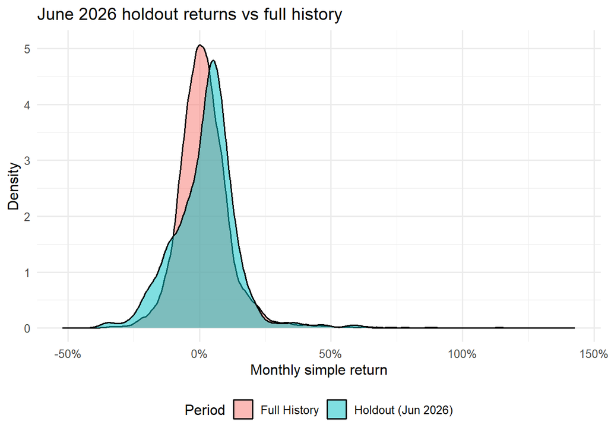

```r
bind_rows(
  tibble(value = returns_history, Period = "Full History"),
  tibble(value = returns_eval,    Period = "Holdout (Jun 2026)")
) |>
  ggplot(aes(value, fill = Period)) +
  geom_density(alpha = 0.5) +
  scale_x_continuous(labels = percent_format(accuracy = 1)) +
  labs(title = "June 2026 holdout returns vs full history",
       x = "Monthly simple return", y = "Density") +
  theme(legend.position = "bottom")
```

Task: For each stock, z-score its June 2026 return against its own return history.

```r
returns_hist_stats <- monthly_returns |>
  filter(month < as.Date("2026-06-01"), !is.na(monthly_return)) |>
  summarise(mean_ret = mean(monthly_return),
            sd_ret   = sd(monthly_return), .by = ticker)

returns_z <- monthly_returns |>
  filter(month == as.Date("2026-06-01")) |>
  left_join(returns_hist_stats, by = "ticker") |>
  mutate(z_return = (monthly_return - mean_ret) / sd_ret)

single_summary_table(returns_z$z_return) |>
  gt_compact(title = "Per-stock z-scores of June 2026 returns vs own history")
```

Per-stock z-scores of June 2026 returns vs own history

| Metric | Value |
| --- | --- |
| N | 499.0000000 |
| Mean | 0.1786067 |
| Std Dev | 1.3191101 |
| Skew | -0.1709294 |
| Kurtosis | 1.0538705 |
| Min | -5.5703251 |
| 5% | -1.9839887 |
| 25% | -0.7023969 |
| 50% | 0.2595595 |
| 75% | 1.0356334 |
| 95% | 2.1262195 |
| Max | 5.4659604 |

Q: Is the holdout month unusual, and why does that matter for evaluating the signal?

A:

- The test of equal means suggests that the central tendency of the training and hold out periods is statitically similar. Moreover, the density plots overlap well. This is also corroborated by the z-score analysis, since the hold out the hold out period’s z-score is near 0; i.e. the average return.
- Taken together, his suggests that the hold out period is not unusual.
- If the June cross-section did have a materially higher mean than history (a positive average z-score; i.e. unusual), a raw-return evaluation can flatter the signal: apparent success may reflect a generally strong month rather than genuine security selection.

## Momentum

Task: Find the cutoffs used in the momentum signal

```r
cutoffs <- momentum_panel |>
  group_by(formation = format(month, "%b %Y")) |>
  summarise(
    q25    = quantile(momentum, 0.25, type = 7, na.rm = TRUE),
    median = median(momentum, na.rm = TRUE),
    q75    = quantile(momentum, 0.75, type = 7, na.rm = TRUE),
    .groups = "drop"
  )

cutoffs |>
  transmute(Formation = formation,
            `25th pct` = pct(q25, 0.1),
            Median = pct(median, 0.1),
            `75th pct` = pct(q75, 0.1)) |>
  gt_compact(title = "Cross-sectional momentum cutoffs at formation")
```

Cross-sectional momentum cutoffs at formation

| Formation | 25th pct | Median | 75th pct |
| --- | --- | --- | --- |
| Jul 2026 | -9.5% | 10.5% | 33.5% |
| Jun 2026 | -6.5% | 12.7% | 34.6% |
| May 2026 | -8.4% | 11.9% | 35.7% |

Task: Create histograms of momentum for each of the 3 hold out periods. Mark the 25th, 50th, and 75th quantiles.

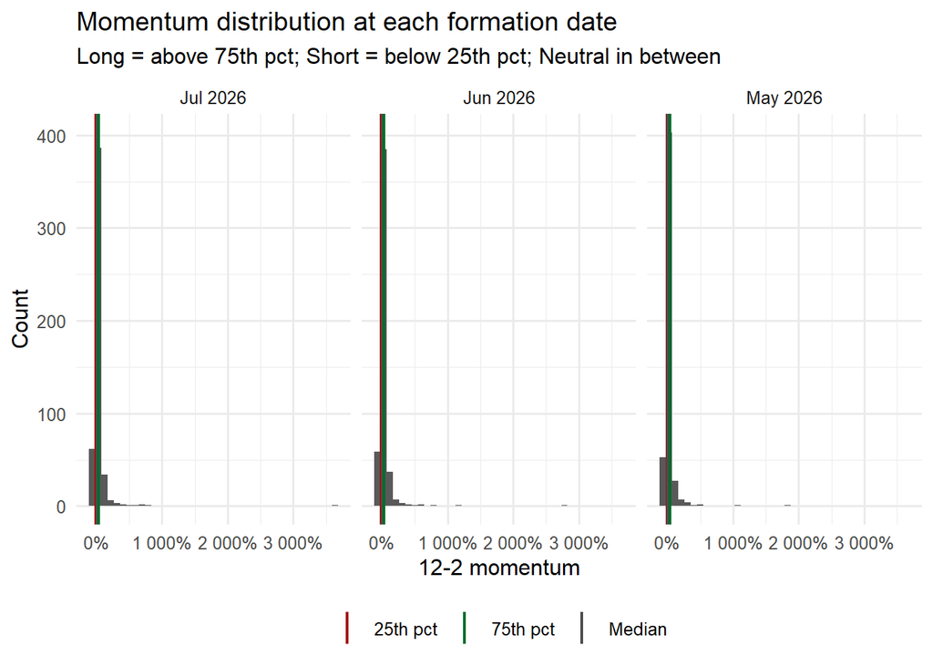

```r
cut_long <- cutoffs |>
  pivot_longer(c(q25, median, q75), names_to = "stat", values_to = "x") |>
  mutate(stat = recode(stat, q25 = "25th pct", median = "Median", q75 = "75th pct"))

momentum_panel |>
  mutate(formation = format(month, "%b %Y")) |>
  ggplot(aes(momentum)) +
  geom_histogram(bins = 40) +
  geom_vline(data = cut_long, aes(xintercept = x, color = stat), linewidth = 0.8) +
  facet_wrap(~ formation) +
  scale_x_continuous(labels = percent_format(accuracy = 1)) +
  scale_color_manual(values = c("25th pct" = "#a50f15", "Median" = "grey30", "75th pct" = "#006d2c")) +
  labs(x = "12-2 momentum", y = "Count", color = NULL,
       title = "Momentum distribution at each formation date",
       subtitle = "Long = above 75th pct; Short = below 25th pct; Neutral in between") +
  theme(legend.position = "bottom")
```

Task: Compute the number of Long, Neutral, and Short in each formation period.

```r
momentum_panel |>
  group_by(month) |>
  mutate(
    q25 = quantile(momentum, 0.25, type = 7, na.rm = TRUE),
    q75 = quantile(momentum, 0.75, type = 7, na.rm = TRUE),
    class = case_when(
      is.na(momentum) ~ "Unavailable",
      momentum > q75 ~ "Long",
      momentum < q25 ~ "Short",
      TRUE ~ "Neutral"
    )
  ) |>
  ungroup() |>
  mutate(formation = format(month, "%b %Y")) |>
  count(formation, class) |>
  pivot_wider(names_from = class, values_from = n, values_fill = 0) |>
  gt_compact(title = "Quartile selection counts by formation month")
```

Quartile selection counts by formation month

| formation | Long | Neutral | Short |
| --- | --- | --- | --- |
| Jul 2026 | 125 | 249 | 125 |
| Jun 2026 | 125 | 249 | 125 |
| May 2026 | 125 | 249 | 125 |

Q: Why 125 Long and 125 Short each formation month?

A: That is by design. We chose the 75th quantile, above which there are 125 longs, and the 25th quantile, below which there are 125 shorts.

Task: Compute the IVV’s momentum at each formation date.

```r
monthly |>
  filter(asset_role == "benchmark") |>
  compute_monthly_returns() |>
  compute_momentum() |>
  filter(month %in% schedule$formation_month) |>
  transmute(`Formation` = format(month, "%b %Y"), `IVV 12-2 momentum` = pct(momentum, 0.1)) |>
  gt_compact(title = "Benchmark momentum at formation")
```

Benchmark momentum at formation

| Formation | IVV 12-2 momentum |
| --- | --- |
| May 2026 | 18.5% |
| Jun 2026 | 23.5% |
| Jul 2026 | 23.5% |

With only ~18 months of price history, 12-2 momentum is computable for just five month-ends (Apr–Aug 2026), so a long per-stock momentum history is unavailable. We instead contrast the momentum cross-section across the three formation months directly.

Task: Contrast the momentum cross-section across the three formation months.

```r
summary_table(
  `May 2026` = momentum_panel |> filter(month == as.Date("2026-05-01")) |> pull(momentum),
  `Jun 2026` = momentum_panel |> filter(month == as.Date("2026-06-01")) |> pull(momentum),
  `Jul 2026` = momentum_panel |> filter(month == as.Date("2026-07-01")) |> pull(momentum)
) |>
  gt_compact(title = "12-2 momentum by formation month")
```

12-2 momentum by formation month

| Metric | May 2026 | Jun 2026 | Jul 2026 |
| --- | --- | --- | --- |
| N | 499.00000000 | 499.00000000 | 499.00000000 |
| Mean | 0.28521109 | 0.33992934 | 0.32533994 |
| Std Dev | 1.12901985 | 1.54187633 | 1.82559183 |
| Skew | 11.03380542 | 12.97816481 | 15.94492872 |
| Kurtosis | 159.15827008 | 214.75752659 | 303.53500491 |
| Min | -0.69767569 | -0.68638660 | -0.70051396 |
| 5% | -0.32841533 | -0.38580013 | -0.37603102 |
| 25% | -0.08405265 | -0.06548202 | -0.09528154 |
| 50% | 0.11851610 | 0.12745023 | 0.10457429 |
| 75% | 0.35683977 | 0.34559725 | 0.33465167 |
| 95% | 1.02164692 | 1.25310262 | 1.15375099 |
| Max | 18.78635985 | 28.09286415 | 36.37552453 |

Q: What would a shift in the momentum distribution across formation months imply for the strategy?

A: Because selection is a within-cross-section quartile rule, a level shift in momentum does not change *how many* names are chosen (always the top and bottom quartiles). It changes *which* names, and a compression or widening of the distribution changes the relative-strength weights ($a_{i,t} = \lvert mom_{i,t} - \tilde{mom}_t \rvert$) that size positions within each sleeve.

## Connecting momentum and returns

Task: Scatter May-formation momentum against the June return it forecasts, with a linear fit.

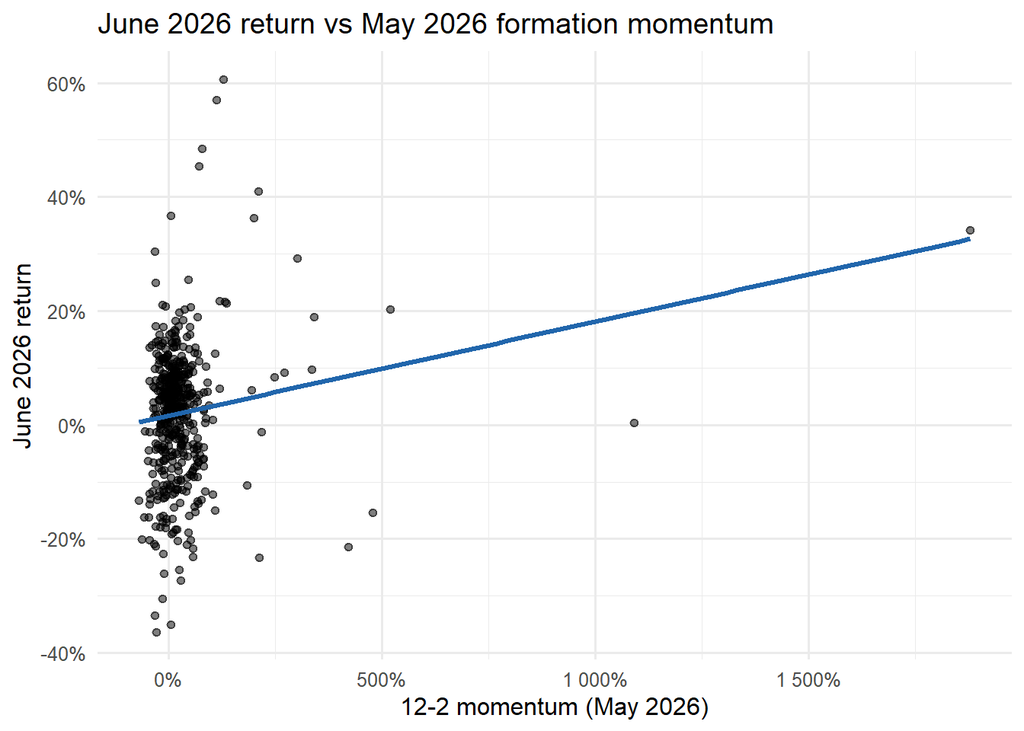

```r
momentum_returns_scatter <- momentum_panel |>
  filter(month == as.Date("2026-05-01")) |>
  select(ticker, momentum) |>
  inner_join(
    monthly_returns |>
      filter(month == as.Date("2026-06-01")) |>
      select(ticker, monthly_return),
    by = "ticker"
  )

ggplot(momentum_returns_scatter, aes(x = momentum, y = monthly_return)) +
  geom_point(alpha = 0.5) +
  geom_smooth(method = "lm", se = FALSE, color = strategy_color) +
  scale_x_continuous(labels = percent_format(accuracy = 1)) +
  scale_y_continuous(labels = percent_format(accuracy = 1)) +
  labs(title = "June 2026 return vs May 2026 formation momentum",
       x = "12-2 momentum (May 2026)", y = "June 2026 return")
```

Task: Identify the highest- and lowest-momentum names at the May formation and plot their indexed monthly prices around the holdout.

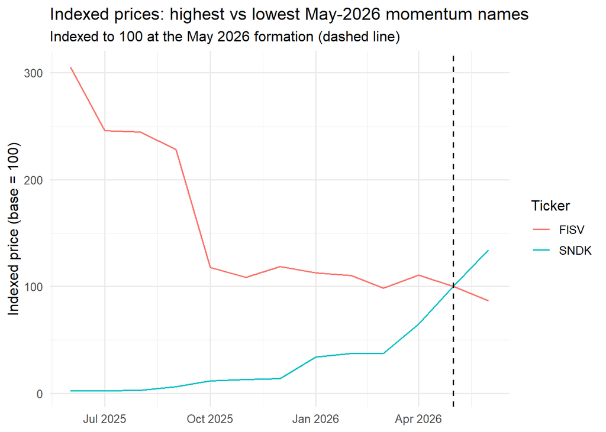

```r
extreme_momentum <- momentum_panel |>
  filter(month == as.Date("2026-05-01"), !is.na(momentum)) |>
  filter(momentum == max(momentum) | momentum == min(momentum)) |>
  select(ticker, momentum)

indexed_prices <- monthly_returns |>
  filter(ticker %in% extreme_momentum$ticker,
         month >= as.Date("2025-06-01"), month <= as.Date("2026-06-01")) |>
  group_by(ticker) |>
  arrange(month, .by_group = TRUE) |>
  mutate(indexed_price = 100 * adjusted_price / adjusted_price[month == as.Date("2026-05-01")]) |>
  ungroup()

ggplot(indexed_prices, aes(x = month, y = indexed_price, color = ticker)) +
  geom_line() +
  geom_vline(xintercept = as.Date("2026-05-01"), linetype = "dashed") +
  labs(title = "Indexed prices: highest vs lowest May-2026 momentum names",
       subtitle = "Indexed to 100 at the May 2026 formation (dashed line)",
       x = NULL, y = "Indexed price (base = 100)", color = "Ticker")
```

Q: How does the scatter relate to the efficacy of the signal?

A: An upward-sloping fit is consistent with higher formation momentum being associated with higher next-month returns — the premise of the strategy. It is only suggestive: the formal cross-sectional test (information coefficient) is computed in the Signal Efficacy section below.

# Single HoldOut

Let’s focus on the May 2026 formation and the June 2026 hold out.

Task: Use the custom compute_asset_daily_returns to compute the returns for each day.

```r
june_row <- schedule |> filter(evaluation_month == as.Date("2026-06-01"))
asset_returns <- compute_asset_daily_returns(daily)
```

## Features

Task: Grab only the June 2026 momentum from the momentum panel for every eiligible constituent.

```r
june_momentum <- momentum_panel |>
  filter(month == june_row$formation_month) |>
  select(ticker, momentum)
```

## Signal

### Cutoffs and median

We summarize the cross-section with three order statistics, using R’s standard empirical quantile convention (`type = 7`) consistently.
$$q_{0.25,t} = Q_{0.25}\big(\{mom_{j,t}\}_j\big), \quad
q_{0.75,t} = Q_{0.75}\big(\{mom_{j,t}\}_j\big), \quad
\tilde{mom}_t = \mathrm{median}_j\big(mom_{j,t}\big).$$

Task: Compute the 25,50,75 quantiles

```r
june_q25 <- quantile(june_momentum$momentum, 0.25, type = 7, na.rm = TRUE)
june_q75 <- quantile(june_momentum$momentum, 0.75, type = 7, na.rm = TRUE)
june_med <- median(june_momentum$momentum, na.rm = TRUE)
c(q25 = june_q25, median = june_med, q75 = june_q75)
```

```
    q25.25%      median     q75.75%
-0.08405265  0.11851610  0.35683977
```

### Signal Construction

The signal converts momentum into **selection and direction** using strict inequalities against the quartile cutoffs. Securities exactly equal to either cutoff stay neutral.
$$s_{i,t} =
\begin{cases}
+1 & mom_{i,t} > q_{0.75,t},\\
-1 & mom_{i,t} < q_{0.25,t},\\
0 & \text{otherwise.}
\end{cases}$$

Task: Generate the signal

```r
june_panel <- june_momentum |>
  mutate(
    q25 = june_q25,
    q75 = june_q75,
    median_mom = june_med,
    signal = case_when(
      is.na(momentum) ~ NA_integer_,
      momentum > q75 ~ 1L,
      momentum < q25 ~ -1L,
      TRUE ~ 0L
    )
  )
```

Q: Why is this a *relative* momentum signal rather than an *absolute* one?

A: Selection is defined by a security’s rank *within the cross-section*, not by any fixed level. The strategy buys cross-sectional winners and shorts cross-sectional losers. In a strong bull market a “short” name can still have positive absolute momentum (it is merely in the bottom quartile); in a bear market a “long” name can have negative absolute momentum. Direction encodes relative standing, not the sign of the raw return.

### Position

The position layer determines whether and when the signal is acted upon. In this exercise there is no separate conviction threshold, timing filter, or regime filter, so
$$s^{pos}_{i,t} = s_{i,t}.$$

Task: Set the position equal to the signal

```r
june_panel <- june_panel |>
  mutate(position = signal)
```

Q: Why keep $s^{pos}$ as a separate object if it equals $s$?

A: The equality is a property of *this* strategy, not of the architecture. Keeping the position layer explicit shows exactly where another strategy would insert a conviction, timing, or regime rule; the layer is present, it simply applies the identity map here. It also keeps the timing discipline visible: a signal formed at month-end only becomes eligible to earn returns on the next trading day.

## Signal Evaluation

Before turning the signal into portfolio weights, we evaluate the quartile signal itself on the June 2026 holdout using the single-holdout engine sourced in Housekeeping. The signal is formed from May 2026 momentum (`june_panel$signal`) and scored against realized June 2026 returns. Unlike an absolute-threshold signal, the quartile rule leaves the middle two quartiles neutral, so coverage is well below 100% and the “Acted Only” view differs from “Overall”.

Task: Assemble the evaluation inputs and shared metadata, then run the single-holdout evaluation with `return_threshold = 0`.

```r
Meta <- list(assetname = "asset", signalname = "Relative-Momentum (quartile)")
return_threshold <- 0

june_signal_position <- june_panel |>
  filter(!is.na(signal)) |>
  transmute(ticker, signal_position = signal)

june_test_returns <- monthly_returns |>
  filter(month == june_row$evaluation_month) |>
  transmute(ticker, test_returns = monthly_return)

SignalEval <- signal_evaluation_singleholdout(
  test_returns     = june_test_returns,
  Meta             = Meta,
  return_threshold = return_threshold,
  signal_position  = june_signal_position
)
```

Q: What if set return threshold very large? What is the (dis)advantage?

A:

- Advantage: You focus on significant returns, which may improve the quality of your trades.
- Disadvantage: You may ignore smaller but consistent returns, which could lead to missed opportunities

Task: Display the trade results.

```r
SignalEval$TradeResults_Percent
```

```
# A tibble: 3 × 5
  `Test Period Returns`  Long Neutral Short   Sum
  <chr>                 <dbl>   <dbl> <dbl> <dbl>
1 r > threshold         0.148   0.357 0.134 0.639
2 r < -threshold        0.102   0.142 0.116 0.361
3 Sum                   0.251   0.499 0.251 1
```

Q: Interpret the trade results. Can you comment on how active was the signal? Connect that to “coverage”.

A:

- We are active roughly 50% of the time (25% Long and 25% short); i.e. coverage is 50%. Meanwhile, 50% of the assets yielded neutral positions. This is an artifact of our quantile rule.
- Among the 25% Long, 14.8% had test period above the threshold returns and 10.2% had test period returns below the threshold.
- Likewise, the Shorts had a greater fraction of test period returns > threshold (13.4%) than below the negative threshold (11.6%).

Task: Display the return distribution by signal (Long / Neutral / Short).

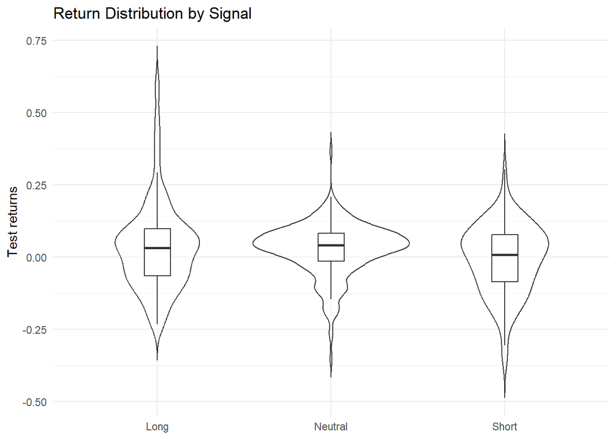

```r
SignalEval$plots$signal
```

Q: What do you notice about the distribution of Longs relative to Neutrals and Shorts?

A: The central tendencies are all rather similar. However, the “right tail” (i.e. high test period returns) is more pronounced for Longs. Meanwhile, neutrals are somewhat symmetric, and Shorts are “left skewed” (i.e. low test period returns). The strongest directional separation appears in the tails rather than near the centers of the distributions.

Q: How might we augment the return_threshold in light of this finding?

A: The signal’s directional separation appears strongest for relatively large return movements. We could therefore increase return_threshold so that positive and negative outcomes represent more substantial test-period returns, while observations with smaller returns are treated as neutral. This would evaluate how well the signal distinguishes economically meaningful movements, although it would also reduce the number of observations classified as positive or negative.

Task: Display the return distribution by signal, faceted by realized-return bucket.

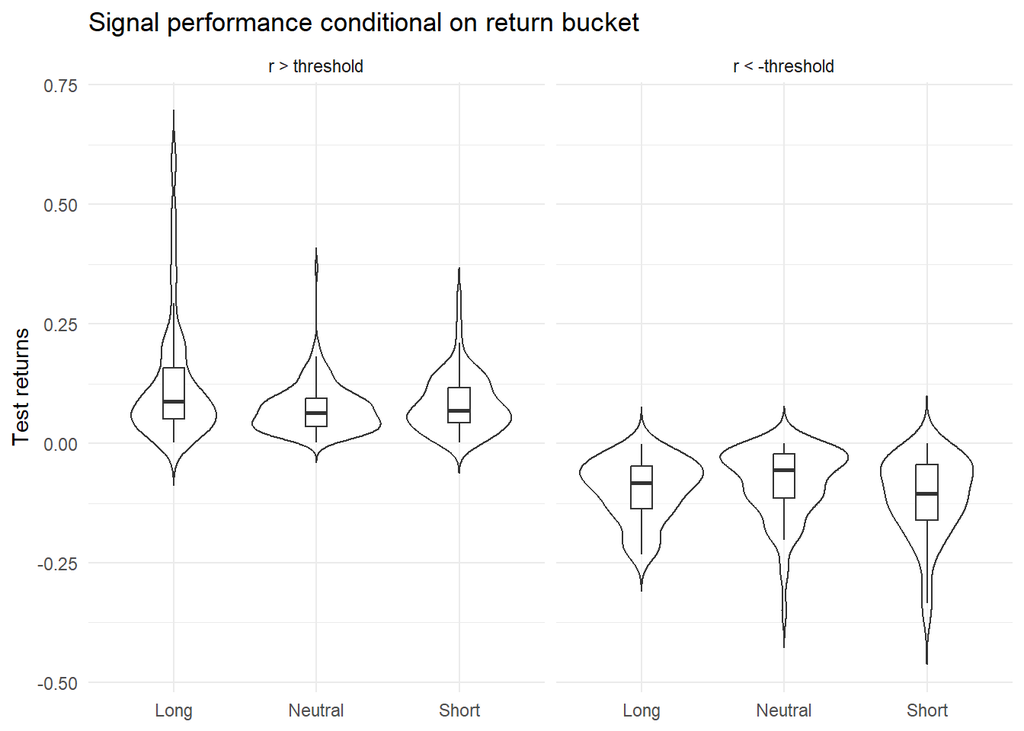

```r
SignalEval$plots$facet
```

Task: Display the return distribution for each signal × outcome intersection.

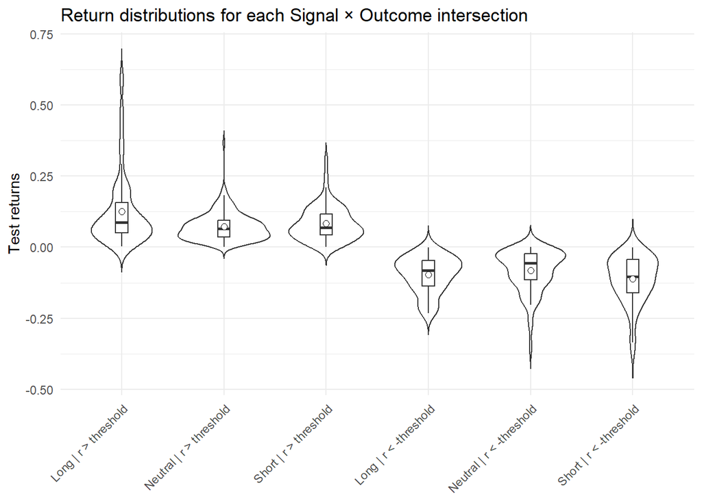

```r
SignalEval$plots$combo
```

Task: Display the hit table.

```r
SignalEval$hit_table
```

```
# A tibble: 6 × 3
  Metric   Overall ActedOnly
  <chr>      <dbl>     <dbl>
1 Hit rate   0.265     0.528
2 Hits     132       132
3 N        499       250
4 z        -10.5       0.885
5 p-value    0         0.376
6 Coverage   0.501     0.501
```

Q: Interpret the Hit Rate of this signal.

A:

Overall

- In 132 of the 499 total observations, the signal took an active position in the same direction as the sign of the test-period return.
- This produces an overall hit rate of 26.5%.
- Given the low p-value this is statistically different from 50%
- Neutral signals cannot count as hits under this definition. Therefore, this measure combines directional accuracy with signal coverage; it is not the proportion of Long, Neutral, and Short classifications that were all correct.

Acted Only

- Among the 250 observations receiving a Long or Short signal, 132 positions were directionally correct: Long with a positive test-period return or Short with a negative test-period return.
- The acted-only hit rate is therefore 52.8%.
- These are the same 132 hits reported in the Overall column.

Task: Display the information coefficient.

```r
SignalEval$summary_ic_tbl
```

```
# A tibble: 4 × 3
  Metric       All Acted_Only
  <chr>      <dbl>      <dbl>
1 IC        0.130      0.154
2 t-stat    2.92       2.46
3 p-value   0.0037     0.0146
4 N       499        250
```

Q: Interpret the IC.

A:

- All observations: The IC of 0.130 indicates a weak positive association between the signal position and subsequent returns. Stocks assigned more positive signals tended to earn somewhat higher test-period returns. With 499 observations, this relationship is statistically significant ((t=2.92), (p=0.0037)).
- Acted only: After excluding Neutral signals, the IC increases to 0.154. Thus, among the 250 Long and Short positions, Long positions tended to outperform Short positions. This relationship is also statistically significant ((t=2.46), (p=0.0146)).
- Overall, the signal contains statistically detectable directional information, but the relatively small IC values indicate that the relationship is modest rather than strong. The IC uses the magnitude of the realized returns and does not depend on return_threshold.

Task: Display the confusion report.

```r
SignalEval$confusion_report
```

```
# A tibble: 13 × 4
   Metric      `Long vs Not-Long` `Short vs Not-Short` `Neutral vs Not-Neutral`
   <fct>                    <dbl>                <dbl>                    <dbl>
 1 TP                       74                   58                         0
 2 FP                       51                   67                       249
 3 FN                      245                  122                         0
 4 TN                      129                  252                       250
 5 n                       499                  499                       499
 6 accuracy                  0.41                 0.62                      0.5
 7 precision                 0.59                 0.46                      0
 8 recall                    0.23                 0.32                     NA
 9 specificity               0.72                 0.79                      0.5
10 type1_error               0.28                 0.21                      0.5
11 type2_error               0.77                 0.68                     NA
12 f1                        0.33                 0.38                     NA
13 mcc                      -0.06                 0.12                     NA
```

Q: Interpret each row of the confusion matrix; skip the f1 and mcc.

A: Because `return_threshold = 0`, the realized-return categories are:

- Positive: (r_{i,}>0)
- Negative: (r_{i,}<0)
- Neutral: (r_{i,}=0)

The predicted classifications come from the relative-momentum signal: Long for the top momentum quartile, Short for the bottom momentum quartile, and Neutral for the middle two quartiles.

**Long versus Not-Long**

A predicted positive means that the relative-momentum signal placed the stock in the top momentum quartile and told us to go Long. A predicted negative, or Not-Long signal, means that the stock received either a Neutral or Short signal.

An actual positive means that the test-period return was positive. An actual negative means that the test-period return was nonpositive.

- **TP (74):** We went Long, and the test-period return was positive.
- **FP (51):** We went Long, but the test-period return was nonpositive.
- **FN (245):** We did not go Long, but the test-period return was positive.
- **TN (129):** We did not go Long, and the test-period return was nonpositive.
- **n (499):** (74+51+245+129=499) observations were included.
- **Accuracy (0.41):** Approximately 41% of the observations were classified correctly: ((74+129)/499=40.7%).
- **Precision (0.59):** Among the observations for which we went Long, 59% subsequently earned a positive return: (74/(74+51)=59.2%).
- **Recall (0.23):** Among the observations that subsequently earned positive returns, we went Long 23% of the time: (74/(74+245)=23.2%).
- **Specificity (0.72):** Among the observations that subsequently earned nonpositive returns, we did not go Long 72% of the time: (129/(129+51)=71.7%).
- **Type I error analogue (0.28):** Among the observations that subsequently earned nonpositive returns, we nevertheless went Long 28% of the time: (51/(51+129)=28.3%).
- **Type II error analogue (0.77):** Among the observations that subsequently earned positive returns, we failed to go Long 77% of the time: (245/(245+74)=76.8%).

**Short versus Not-Short**

A predicted positive means that the relative-momentum signal placed the stock in the bottom momentum quartile and told us to go Short. A predicted negative, or Not-Short signal, means that the stock received either a Neutral or Long signal.

For this classification, an actual positive means that the test-period return was negative—the outcome anticipated by a Short signal. An actual negative means that the test-period return was nonnegative.

- **TP (58):** We went Short, and the test-period return was negative.
- **FP (67):** We went Short, but the test-period return was nonnegative.
- **FN (122):** We did not go Short, but the test-period return was negative.
- **TN (252):** We did not go Short, and the test-period return was nonnegative.
- **n (499):** (58+67+122+252=499) observations were included.
- **Accuracy (0.62):** Approximately 62% of the observations were classified correctly: ((58+252)/499=62.1%).
- **Precision (0.46):** Among the observations for which we went Short, 46% subsequently earned a negative return: (58/(58+67)=46.4%).
- **Recall (0.32):** Among the observations that subsequently earned negative returns, we went Short 32% of the time: (58/(58+122)=32.2%).
- **Specificity (0.79):** Among the observations that subsequently earned nonnegative returns, we did not go Short 79% of the time: (252/(252+67)=79.0%).
- **Type I error analogue (0.21):** Among the observations that subsequently earned nonnegative returns, we nevertheless went Short 21% of the time: (67/(67+252)=21.0%).
- **Type II error analogue (0.68):** Among the observations that subsequently earned negative returns, we failed to go Short 68% of the time: (122/(122+58)=67.8%).

**Neutral versus Not-Neutral**

A predicted positive means that the relative-momentum signal placed the stock in the middle two momentum quartiles and assigned it a Neutral signal. A predicted negative, or Not-Neutral signal, means that the stock received either a Long or Short signal.

Because `return_threshold = 0`, an actual Neutral outcome requires the test-period return to equal exactly zero. An actual Not-Neutral outcome means that the return was either positive or negative.

- **TP (0):** No stock received a Neutral signal and subsequently earned a return of exactly zero.
- **FP (249):** The signal was Neutral, but the test-period return was nonzero.
- **FN (0):** No actual Neutral outcomes were missed because none of the test-period returns equaled exactly zero.
- **TN (250):** The signal was Long or Short, and the test-period return was nonzero.
- **n (499):** (0+249+0+250=499) observations were included.
- **Accuracy (0.50):** Approximately 50% of the observations were classified correctly: (250/499=50.1%).
- **Precision (0.00):** None of the 249 Neutral signals corresponded to a test-period return of exactly zero.
- **Recall (NA):** Recall cannot be calculated because there were no actual Neutral outcomes.
- **Specificity (0.50):** Among the observations with nonzero returns, 50% received a Long or Short signal: (250/(250+249)=50.1%).
- **Type I error analogue (0.50):** Among the observations with nonzero returns, 50% nevertheless received a Neutral signal: (249/(249+250)=49.9%).
- **Type II error analogue (NA):** This rate cannot be calculated because there were no actual Neutral outcomes.

The Neutral confusion matrix is not very informative in this exercise. With `return_threshold = 0`, a realized return is classified as Neutral only when it equals exactly zero—an unlikely outcome for a monthly stock return. Consequently, the nearly equal numbers of false positives and true negatives primarily reflect the signal’s construction: 249 stocks received Neutral signals, while 250 received Long or Short signals.

Q: Focus on the Long-versus-Not-Long classification. Recall the concepts of Type I and Type II errors from hypothesis testing. What is the implicit null hypothesis in this setting? Keep in mind that we are using hypothesis-testing language only as an analogy; the signal is not conducting a formal statistical test.

A:

Let $\tau$ denote `return_threshold`. The implicit hypotheses concern the stock’s realized test-period return:

$$H_0:r_{i,\mathrm{Test}}\leq\tau
\qquad\text{versus}\qquad
H_1:r_{i,\mathrm{Test}}>\tau.$$

The signal’s classification is analogous to a testing decision:

- A **Long** signal is analogous to rejecting (H_0).
- A **Not-Long** signal—either Neutral or Short—is analogous to failing to reject (H_0).

The corresponding classification errors are:

- **Type I error analogue:** The signal says Long, but the realized return does not exceed the threshold.

$$\Pr\!\left(\text{Long}\mid r_{i,\mathrm{Test}}\leq\tau\right).$$

- **Type II error analogue:** The signal says Not-Long, but the realized return exceeds the threshold.

$$\Pr\!\left(\text{Not-Long}\mid r_{i,\mathrm{Test}}>\tau\right).$$

Because this exercise sets $\tau=0$, these become:

$$H_0:r_{i,\mathrm{Test}}\leq0
\qquad\text{versus}\qquad
H_1:r_{i,\mathrm{Test}}>0.$$

Thus, the Type I error analogue is going Long when the subsequent return is nonpositive, while the Type II error analogue is remaining Neutral or going Short when the subsequent return is positive. We say “fail to reject” rather than “accept” (H_0), because a Not-Long signal does not establish that the null is true.

### Evaluate relative to benchmark

In the following we will construct excess returns; constituent return minus the benchmark and then rerun the signal construction and evaluation.

Q: What is the motivation for using excess returns?

A:

- The June cross-section can be flattered by a generally strong month (see the returns EDA).
- Re-scoring on **excess returns** (constituent minus IVV) with `return_threshold = 0` asks whether long names *outperformed* the index and short names *underperformed* it.

Task: Subtract the IVV June return from each constituent and re-run the evaluation.

```r
june_index_return <- monthly |>
  filter(asset_role == "benchmark") |>
  compute_monthly_returns() |>
  filter(month == june_row$evaluation_month) |>
  pull(monthly_return)

june_excess_returns <- june_test_returns |>
  mutate(test_returns = test_returns - june_index_return)

SignalEvalBenchmark <- signal_evaluation_singleholdout(
  test_returns     = june_excess_returns,
  Meta             = Meta,
  return_threshold = 0,
  signal_position  = june_signal_position
)
```

Task: Display the benchmark-relative hit table.

```r
SignalEvalBenchmark$hit_table
```

```
# A tibble: 6 × 3
  Metric   Overall ActedOnly
  <chr>      <dbl>     <dbl>
1 Hit rate   0.263     0.524
2 Hits     131       131
3 N        499       250
4 z        -10.6       0.759
5 p-value    0         0.448
6 Coverage   0.501     0.501
```

Q: What does the Hit Rate on excess returns suggest?

A: The acted-only hit rate decreases only slightly, from 52.8% using raw returns to 52.4% using excess returns. Thus, subtracting the IVV return changes the aggregate directional hit rate very little. This suggests that the raw hit rate was not materially inflated by the strong market return. However, Long and Short classifications could change in offsetting directions, so we would need to examine the two sleeves separately before drawing a definitive conclusion.

Q: Why focus on Acted only when comparing excess returns to raw returns?

A: Neutral signals can never count as hits under the function’s hit-rate definition, so the Overall rate primarily combines directional success with coverage.

Task: Display the information coefficient table.

```r
SignalEvalBenchmark$summary_ic_tbl
```

```
# A tibble: 4 × 3
  Metric       All Acted_Only
  <chr>      <dbl>      <dbl>
1 IC        0.130      0.154
2 t-stat    2.92       2.46
3 p-value   0.0037     0.0146
4 N       499        250
```

Q: Why is the cross-sectional IC essentially unchanged when we switch to excess returns?

A: Subtracting the *same* index return from every stock within a month is a constant shift of the cross-section. It re-labels which stocks count as “positive” (affecting the hit rate and confusion matrix) but leaves the cross-sectional covariance between signal and return — and therefore the IC — essentially unchanged.

## Strategy

### Relative momentum strength

Relative strength measures how far a security’s momentum lies from the center of the formation-date cross-section:
$$a_{i,t} = \lvert mom_{i,t} - \tilde{mom}_t \rvert$$

Task: Add relative momentum to the June panel

```r
june_panel <- june_panel |>
  mutate(relative_strength = abs(momentum - median_mom))
```

### Raw strategy weights

The raw weight is where the strategy goes **beyond copying the signal**: it keeps the signal’s direction but also sets relative size from $a_{i,t}$.
$$w^{raw}_{i,t} = s^{pos}_{i,t}\, a_{i,t} = s^{pos}_{i,t}\,\lvert mom_{i,t} - \tilde{mom}_t \rvert.$$

Task: Construct the strategy raw weight

```r
june_panel <- june_panel |>
  mutate(raw_weight = as.numeric(position) * relative_strength)
```

Q: How does $w^{raw}$ differ from the signal?

A: The signal is a three-valued selector ($-1/0/+1$). The raw weight preserves that direction but scales it by distance from the median: top-quartile names get positive raw weights, bottom-quartile names negative, neutral names exactly zero, and a name farther from the median gets a larger raw position within its sleeve. The signal decides *who and which way*; the raw weight adds *how much, relatively*.

### Scaled strategy weights

The long and short sleeves are normalized **separately** so each sleeve’s shares sum to one in magnitude:
$$G^{+}_t = \!\!\sum_{j:\,w^{raw}_{j,t}>0}\!\! w^{raw}_{j,t}, \quad
G^{-}_t = \!\!\sum_{j:\,w^{raw}_{j,t}<0}\!\! \lvert w^{raw}_{j,t}\rvert,$$
$$w^{scaled}_{i,t} =
\begin{cases}
w^{raw}_{i,t}/G^{+}_t & w^{raw}_{i,t} > 0,\\
w^{raw}_{i,t}/G^{-}_t & w^{raw}_{i,t} < 0,\\
0 & w^{raw}_{i,t} = 0,
\end{cases}$$
so that $\sum_{i:\,w^{scaled}>0} w^{scaled}_{i,t} = 1$ and $\sum_{i:\,w^{scaled}<0} w^{scaled}_{i,t} = -1$.

Q: What is the motivation for normalizing the sleeves separarely? What if we normalized all the raw weights together?

A:

- We normalize the long and short sleeves separately so that the raw signals determine only the relative weights within each sleeve. After normalization, the long weights form a (+1) allocation and the short weights form a (-1) allocation.
- This prevents differences in the aggregate magnitudes of the positive and negative raw signals from unintentionally determining the portfolio’s long–short exposure. We can then deliberately assign the desired exposure to each sleeve—for example, (120%) to the long sleeve and (20%) to the short sleeve.
- If all raw weights were normalized together, the relative sizes of the positive and negative raw signals would determine the long and short exposures. Separate normalization instead makes sleeve exposure an explicit portfolio-design choice.

Task: Compute per-sleeve gross sums and normalize so the long sleeve sums to +1 and the short sleeve to -1.

```r
june_Gpos <- sum(june_panel$raw_weight[june_panel$raw_weight > 0], na.rm = TRUE)
june_Gneg <- sum(abs(june_panel$raw_weight[june_panel$raw_weight < 0]), na.rm = TRUE)

june_panel <- june_panel |>
  mutate(
    scaled_weight = case_when(
      is.na(raw_weight) ~ NA_real_,
      raw_weight > 0 ~ raw_weight / june_Gpos,
      raw_weight < 0 ~ raw_weight / june_Gneg,
      TRUE ~ 0
    )
  )

june_Gpos
```

```
[1] 125.2709
```

```r
june_Gneg
```

```
[1] 44.29104
```

Q: What is the value of june_Gpos and june_Gneg? What do these value mean?

A:

- `june_Gpos = 125.2709`: the sum of the positive raw weights assigned to securities in the long sleeve.
- `june_Gneg = 44.2910`: the sum of the absolute values of the negative raw weights assigned to securities in the short sleeve.
- These are normalization constants used to scale the long weights to sum to (+1) and and the short weights to sum to (-1).

Task: Display the head of the june_panel

```r
head(june_panel)
```

```
# A tibble: 6 × 10
  ticker momentum     q25   q75 median_mom signal position relative_strength
  <chr>     <dbl>   <dbl> <dbl>      <dbl>  <int>    <int>             <dbl>
1 A        0.0680 -0.0841 0.357      0.119      0        0            0.0505
2 AAPL     0.200  -0.0841 0.357      0.119      0        0            0.0810
3 ABBV     0.142  -0.0841 0.357      0.119      0        0            0.0231
4 ABNB     0.0358 -0.0841 0.357      0.119      0        0            0.0828
5 ABT     -0.204  -0.0841 0.357      0.119     -1       -1            0.322
6 ACGL     0.0586 -0.0841 0.357      0.119      0        0            0.0600
# ℹ 2 more variables: raw_weight <dbl>, scaled_weight <dbl>
```

Q: Interpret the raw weight and scaled weight for ABT.

A:

- raw_weight = -0.322: ABT receives a negative strategy score because it is classified as a short position. This is not yet a portfolio percentage.
- scaled_weight = -0.00728: ABT represents approximately (0.728%) of the short sleeve. The negative sign indicates a short position.

Q: What information does $w^{scaled}$ contain, and what does it *not* yet contain?

A: $w^{scaled}$ contains the **within-sleeve allocation shares**: how each sleeve is divided among its selected securities. It does *not* yet contain the portfolio’s long/short capital budgets; the long sleeve sums to $+1$ and the short sleeve to $-1$ regardless of how much capital we ultimately assign to each side.

## Portfolio

The 120/20 decision lives **exclusively** in the portfolio layer. Because short scaled weights are already negative, we multiply them by the *positive* budget $B_S$ (no extra sign):
$$w^{p}_{i,t} =
\begin{cases}
B_L\, w^{scaled}_{i,t} & w^{scaled}_{i,t} > 0,\\
B_S\, w^{scaled}_{i,t} & w^{scaled}_{i,t} < 0,\\
0 & w^{scaled}_{i,t} = 0.
\end{cases}$$

Task: Apply the 120/20 sleeve budgets to the scaled weights to produce the final portfolio weights.

```r
june_panel <- june_panel |>
  mutate(
    portfolio_weight = case_when(
      is.na(scaled_weight) ~ NA_real_,
      scaled_weight > 0 ~ settings$B_L * scaled_weight,
      scaled_weight < 0 ~ settings$B_S * scaled_weight,
      TRUE ~ 0
    ),
    formation_date   = june_row$formation_date,
    effective_date   = june_row$effective_date,
    evaluation_month = june_row$evaluation_month
  )
```

Q: Why does the 120/20 rule belong in $w^{p}$ and not earlier — and why is the portfolio 140% gross but 100% net?

A: Selection (signal), direction (position), and within-sleeve sizing ($w^{raw}$, $w^{scaled}$) are all decisions about *the strategy*. How much capital and leverage to commit to each sleeve is a *portfolio* decision, kept separate so it can change without touching the strategy. Applying $B_L=1.20$ to a long sleeve that sums to $+1$ gives $+1.20$; applying $B_S=0.20$ to a short sleeve that sums to $-1$ gives $-0.20$. Gross exposure is $1.20 + 0.20 = 1.40$ (140%) while net exposure is $1.20 - 0.20 = 1.00$ (100%).

## Summary

### Tracing the transformation

Task: Trace representative **long**, **neutral**, and **short** names through every layer so the full feature → portfolio transformation is legible in one place.

```r
trace_ids <- bind_rows(
  june_panel |> filter(position == 1L)  |> arrange(desc(momentum)) |> slice_head(n = 2),
  june_panel |> filter(position == 0L)  |> arrange(abs(momentum - median_mom)) |> slice_head(n = 2),
  june_panel |> filter(position == -1L) |> arrange(momentum) |> slice_head(n = 2)
)

trace_ids |>
  transmute(
    ticker,
    momentum = pct(momentum, 0.1),
    `25th pct` = pct(q25, 0.1),
    median = pct(median_mom, 0.1),
    `75th pct` = pct(q75, 0.1),
    signal, position,
    `rel. strength` = round(relative_strength, 3),
    raw_weight = round(raw_weight, 3),
    scaled_weight = round(scaled_weight, 4),
    portfolio_weight = round(portfolio_weight, 4)
  ) |>
  gt_compact(title = "Feature to portfolio weight (representative long / neutral / short names)")
```

Feature to portfolio weight (representative long / neutral / short names)

| ticker | momentum | 25th pct | median | 75th pct | signal | position | rel. strength | raw_weight | scaled_weight | portfolio_weight |
| --- | --- | --- | --- | --- | --- | --- | --- | --- | --- | --- |
| SNDK | 1 878.6% | -8.4% | 11.9% | 35.7% | 1 | 1 | 18.668 | 18.668 | 0.1490 | 0.1788 |
| LITE | 1 090.3% | -8.4% | 11.9% | 35.7% | 1 | 1 | 10.785 | 10.785 | 0.0861 | 0.1033 |
| HBAN | 11.9% | -8.4% | 11.9% | 35.7% | 0 | 0 | 0.000 | 0.000 | 0.0000 | 0.0000 |
| LH | 11.9% | -8.4% | 11.9% | 35.7% | 0 | 0 | 0.000 | 0.000 | 0.0000 | 0.0000 |
| FISV | -69.8% | -8.4% | 11.9% | 35.7% | -1 | -1 | 0.816 | -0.816 | -0.0184 | -0.0037 |
| IT | -62.4% | -8.4% | 11.9% | 35.7% | -1 | -1 | 0.742 | -0.742 | -0.0168 | -0.0034 |

### Exposure reconciliation

Task: Reconcile the June portfolio exposures (long, short, gross, net) against the 120/20 mandate.

```r
exposure_summary(june_panel) |>
  transmute(
    `# Long` = n_long, `# Short` = n_short,
    Long = pct(long_exposure), Short = pct(short_exposure),
    Gross = pct(gross_exposure), Net = pct(net_exposure)
  ) |>
  gt_compact(title = "June exposure reconciliation",
             subtitle = "Long 120%, short -20%, gross 140%, net 100%")
```

June exposure reconciliation

Long 120%, short -20%, gross 140%, net 100%

| # Long | # Short | Long | Short | Gross | Net |
| --- | --- | --- | --- | --- | --- |
| 125 | 125 | 120.0% | -20.0% | 140.0% | 100.0% |

Q: Interpret each column of this table.

A:

- Long (125): The portfolio holds 125 long positions.
- Short (125): The portfolio holds 125 short positions.
- Long (120%): The long sleeve equals 120% of initial equity.
- Short (-20%): The short sleeve equals (-20%) of initial equity.
- Gross (140%): Total absolute exposure is 140% of initial equity, implying (1.4) leverage.
- Net (100%): Long exposure plus short exposure is (120%-20%=100%) of initial equity.

### Strategy evaluation

We hold the June target weights constant through the month (frictionless daily rebalancing) and compute daily security contributions and portfolio returns from the **final portfolio weights**:
$$C_{i,d} = w^{p}_{i,t}\, R_{i,d}, \qquad R_{p,d} = \sum_i C_{i,d}.$$

Task: Compute daily security contributions, portfolio returns, and the benchmark’s daily returns for June.

```r
june_contrib <- build_daily_contributions(june_panel, asset_returns)
june_port    <- aggregate_portfolio_returns(june_contrib)
june_bench   <- benchmark_daily_returns(asset_returns, settings$benchmark, june_port$date)
```

Task: Summarize June performance versus IVV (total return, active return, volatility, Sharpe, max drawdown, beta).

```r
performance_metrics(june_port, june_bench, settings, settings$labels["strategy"]) |>
  transmute(
    Portfolio = portfolio,
    `Total return` = pct(total_return, 0.01),
    `Active vs IVV` = ppts(active_return),
    `Ann. vol` = pct(ann_volatility),
    Sharpe = round(sharpe, 2),
    `Max DD` = pct(max_drawdown, 0.01),
    Beta = round(beta, 2)
  ) |>
  gt_compact(title = "June performance vs IVV",
             subtitle = "One month of daily data: risk statistics are illustrative")
```

June performance vs IVV

One month of daily data: risk statistics are illustrative

| Portfolio | Total return | Active vs IVV | Ann. vol | Sharpe | Max DD | Beta |
| --- | --- | --- | --- | --- | --- | --- |
| Relative-Momentum 120/20 | 11.64% | 13.5 ppts | 66.8% | 2.3 | -10.16% | 2.72 |

Q: Describe the strategy via the performance metrics.

A:

- The 11.64% return was 13.5ppts greater than the IVV
- Despite the larger 66.8% volatility, the Sharpe ratio was still a large positive
- The strategy was down more than 10% at it’s worst
- The strategy’s beta of 2.72 suggests it is highly exposed to market risk

Task: Plot the June growth of $100 for the strategy versus IVV.

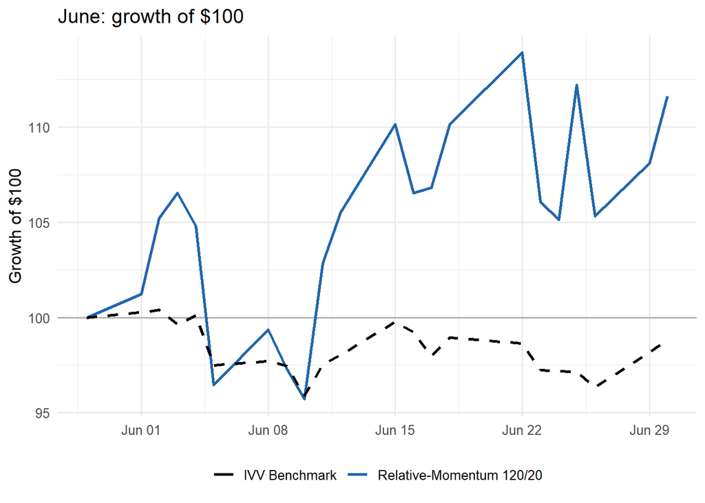

```r
june_curves <- bind_rows(
  june_port  |> transmute(date, index = equity_index, Series = settings$labels["strategy"]),
  june_bench |> transmute(date, index = benchmark_index, Series = settings$labels["benchmark"])
)
anchor <- june_curves |> distinct(Series) |> mutate(date = june_row$formation_date, index = 100)

bind_rows(anchor, june_curves) |>
  ggplot(aes(date, index, color = Series)) +
  geom_hline(yintercept = 100, color = "grey70") +
  geom_line(aes(linetype = Series == settings$labels["benchmark"]), linewidth = 0.9) +
  scale_linetype_manual(values = c("solid", "dashed"), guide = "none") +
  scale_color_manual(values = setNames(c(strategy_color, benchmark_color),
                                       settings$labels[c("strategy", "benchmark")])) +
  labs(x = NULL, y = "Growth of $100", color = NULL, title = "June: growth of $100") +
  theme(legend.position = "bottom")
```

### Attribution analysis

Security and sleeve attribution use the **portfolio weights** and are Carino-linked so the linked contributions reconcile geometrically to the compounded portfolio return.

Task: Compute and chart June security attribution (Carino-linked) by contributor bucket.

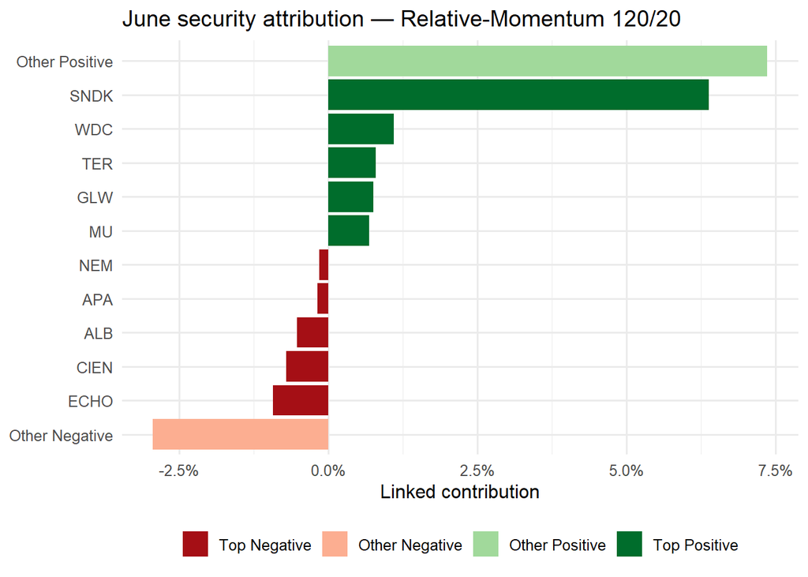

```r
june_sec    <- security_attribution(june_contrib, june_port)
june_sleeve <- sleeve_attribution(june_sec)

contributor_buckets(june_sec) |>
  mutate(bucket = factor(bucket, levels = names(bucket_colors))) |>
  ggplot(aes(x = contribution, y = reorder(ticker, contribution), fill = bucket)) +
  geom_col() +
  scale_fill_manual(values = bucket_colors) +
  scale_x_continuous(labels = percent_format(accuracy = 0.1)) +
  labs(x = "Linked contribution", y = NULL, fill = NULL,
       title = "June security attribution — Relative-Momentum 120/20") +
  theme(legend.position = "bottom")
```

Q: What’s the purpose of the Carino-linking?

A: We’re linking daily security contributions across multiple days into a single multi-period attribution. Within a day, contributions are additive; they sum exactly to that day’s portfolio return. But summing daily contributions *across days* doesn’t equal the compounded multi-period return, since returns compound geometrically, not arithmetically. Carino-linking rescales each day’s contributions by a factor ($k_d/K$) so that summing across both days and securities reproduces the exact compounded total return.

Task: Summarize June sleeve-level attribution.

```r
june_sleeve |>
  transmute(Sleeve = sleeve, Contribution = ppts(contribution)) |>
  gt_compact(title = "June sleeve attribution")
```

June sleeve attribution

| Sleeve | Contribution |
| --- | --- |
| Long | 11.4 ppts |
| Short | 0.3 ppts |

Q: Interpret these contributions.

A:

- Within June, 11.4pts were earned by the long positions and another 0.3ppts from the shorts.
- Combining these two equals the total return for the month.

Task: Perform quick reconciliation checks

```r
june_active <- active_daily_returns(june_port, june_bench)
june_mc <- monthly_and_cumulative(june_port)
june_checks <- bind_rows(
  validate_weights(june_panel),
  validate_returns(june_contrib, june_port, june_active, june_mc, june_row),
  validate_attribution(june_sec, june_sleeve, june_port)
)
assert_checks(june_checks, "June reconciliation")
```

```
# A tibble: 21 × 3
   check                                                      passed detail
   <chr>                                                      <lgl>  <chr>
 1 signals in {-1,0,1} or NA                                  TRUE   ""
 2 percentile cutoffs computed per formation month (type = 7) TRUE   ""
 3 position == signal                                         TRUE   ""
 4 cutoff ties are neutral                                    TRUE   ""
 5 neutral names carry zero raw/scaled/portfolio weight       TRUE   ""
 6 long raw weights > 0 and short raw weights < 0             TRUE   ""
 7 each formation month has non-empty long and short sleeves  TRUE   "min long …
 8 scaled long weights sum to +1                              TRUE   ""
 9 scaled short weights sum to -1                             TRUE   ""
10 portfolio long weights sum to +1.20                        TRUE   ""
# ℹ 11 more rows
```

```r
june_checks |>
  transmute(Check = check, Status = ifelse(passed, "PASS", "FAIL"), Detail = detail) |>
  gt_compact(title = "June reconciliation checks")
```

June reconciliation checks

| Check | Status | Detail |
| --- | --- | --- |
| signals in {-1,0,1} or NA | PASS |  |
| percentile cutoffs computed per formation month (type = 7) | PASS |  |
| position == signal | PASS |  |
| cutoff ties are neutral | PASS |  |
| neutral names carry zero raw/scaled/portfolio weight | PASS |  |
| long raw weights > 0 and short raw weights < 0 | PASS |  |
| each formation month has non-empty long and short sleeves | PASS | min long 125, min short 125 |
| scaled long weights sum to +1 | PASS |  |
| scaled short weights sum to -1 | PASS |  |
| portfolio long weights sum to +1.20 | PASS |  |
| portfolio short weights sum to -0.20 | PASS |  |
| portfolio net exposure = 1.00 | PASS |  |
| portfolio gross exposure = 1.40 | PASS |  |
| no missing-weight propagation among eligible names | PASS |  |
| daily return = sum of contributions | PASS | max diff 0.00e+00 |
| equity index = compounded returns | PASS |  |
| monthly returns compound to cumulative | PASS |  |
| active = portfolio - benchmark | PASS |  |
| first eligible return is after formation date | PASS |  |
| linked security contributions reconcile to compounded return | PASS | diff 1.53e-16 |
| sleeve contributions reconcile to security total | PASS | diff 0.00e+00 |

# Multiple Hold outs

## Abstracting the construction

Let’s create a local function to reproduce the single holdout approach in a loop.

Task: Define a local `build_portfolio_panel()` function that reproduces the inline single-holdout construction (signal → position → raw → scaled → portfolio weights).

```r
build_portfolio_panel <- function(momentum_df) {
  # Cutoffs and median of this formation-date cross-section (type-7 quantiles).
  q25 <- quantile(momentum_df$momentum, 0.25, type = 7, na.rm = TRUE)
  q75 <- quantile(momentum_df$momentum, 0.75, type = 7, na.rm = TRUE)
  med <- median(momentum_df$momentum, na.rm = TRUE)

  panel <- momentum_df |>
    mutate(
      q25 = q25,
      q75 = q75,
      median_mom = med,
      # signal: relative quartile selection, strict inequalities, ties neutral
      signal = case_when(
        is.na(momentum) ~ NA_integer_,
        momentum > q75 ~ 1L,
        momentum < q25 ~ -1L,
        TRUE ~ 0L
      ),
      # position equals signal (no extra conviction/timing/regime rule)
      position = signal,
      # relative strength: distance from the cross-sectional median
      relative_strength = abs(momentum - median_mom),
      # raw weight: signed, magnitude from relative strength
      raw_weight = as.numeric(position) * relative_strength
    )

  # per-sleeve gross sums for normalization
  Gpos <- sum(panel$raw_weight[panel$raw_weight > 0], na.rm = TRUE)
  Gneg <- sum(abs(panel$raw_weight[panel$raw_weight < 0]), na.rm = TRUE)

  panel |>
    mutate(
      # scaled weight: long sleeve sums to +1, short sleeve to -1
      scaled_weight = case_when(
        is.na(raw_weight) ~ NA_real_,
        raw_weight > 0 ~ raw_weight / Gpos,
        raw_weight < 0 ~ raw_weight / Gneg,
        TRUE ~ 0
      ),
      # portfolio weight: apply the 120/20 sleeve budgets
      portfolio_weight = case_when(
        is.na(scaled_weight) ~ NA_real_,
        scaled_weight > 0 ~ settings$B_L * scaled_weight,
        scaled_weight < 0 ~ settings$B_S * scaled_weight,
        TRUE ~ 0
      )
    )
}
```

We apply that function separately at each of the three formation dates, recomputing the signal and portfolio weights each month. The May formation is evaluated in June, the June formation in July, and the July formation in August. We then combine these three monthly holdouts into one continuous June–August portfolio history.

Task: Map the construction across all schedule rows to build one continuous portfolio history, then compute contributions, portfolio returns, and benchmark returns.

```r
panel <- build_complete_panel(momentum_panel, schedule, build_portfolio_panel)

contrib <- build_daily_contributions(panel, asset_returns)
port    <- aggregate_portfolio_returns(contrib)
bench   <- benchmark_daily_returns(asset_returns, settings$benchmark, port$date)
```

## Strategy performance

Task: Build a side-by-side performance summary for the strategy and IVV. Report each portfolio’s total return (using raw, not excess returns), annualized volatility, maximum drawdown, and Sharpe ratio. Also report the strategy’s active return relative to IVV, monthly reconstitution turnover, and turnover-adjusted Sharpe ratio.

```r
to_events <- turnover_events(panel, schedule)
wk        <- weekly_turnover(to_events)

strat_summ <- performance_metrics(port, bench, settings, settings$labels["strategy"]) |>
  mutate(avg_weekly_to = wk$avg_weekly,
         sr_to = turnover_adjusted_sharpe(sharpe, avg_weekly_to, settings))

bench_summ <- performance_metrics(
  bench |> transmute(date, evaluation_month = floor_date(date, "month"),
                     portfolio_return = benchmark_return),
  settings = settings, label = settings$labels["benchmark"]
)

bind_rows(strat_summ, bench_summ) |>
  transmute(
    Portfolio = portfolio,
    `Total return` = pct(total_return, 0.01),
    `Active vs IVV` = ifelse(is.na(active_return), NA, ppts(active_return)),
    `Ann. vol` = pct(ann_volatility),
    `Max DD` = pct(max_drawdown, 0.01),
    Sharpe = round(sharpe, 2),
    `Turnover (wk)` = ifelse(is.na(avg_weekly_to), NA, round(avg_weekly_to, 3)),
    `Sharpe (TO-adj)` = ifelse(is.na(sr_to), NA, round(sr_to, 2))
  ) |>
  gt_compact(title = "Performance summary (Jun-Aug 2026)",
             subtitle = "~3 months of daily data: risk and relative statistics are illustrative")
```

Performance summary (Jun-Aug 2026)

~3 months of daily data: risk and relative statistics are illustrative

| Portfolio | Total return | Active vs IVV | Ann. vol | Max DD | Sharpe | Turnover (wk) | Sharpe (TO-adj) |
| --- | --- | --- | --- | --- | --- | --- | --- |
| Relative-Momentum 120/20 | -7.28% | -7.9 ppts | 72.6% | -34.62% | -0.06 | 0.09 | -0.11 |
| IVV Benchmark | 1.68% | — | 13.8% | -4.47% | 0.55 | — | — |

## Monthly and cumulative returns

Task: Tabulate monthly and cumulative returns for the strategy and benchmark.

```r
monthly_row <- function(port, label) {
  mc <- monthly_and_cumulative(port)
  mc$monthly |>
    mutate(Portfolio = label, month = format(evaluation_month, "%b")) |>
    select(Portfolio, month, monthly_return) |>
    pivot_wider(names_from = month, values_from = monthly_return) |>
    mutate(Cumulative = mc$cumulative)
}
bench_port <- bench |> transmute(date, evaluation_month = floor_date(date, "month"),
                                 portfolio_return = benchmark_return)
bind_rows(
  monthly_row(port, settings$labels["strategy"]),
  monthly_row(bench_port, settings$labels["benchmark"])
) |>
  mutate(across(where(is.numeric), ~ pct(.x, 0.01))) |>
  gt_compact(title = "Monthly and cumulative returns")
```

Monthly and cumulative returns

| Portfolio | Jun | Jul | Aug | Cumulative |
| --- | --- | --- | --- | --- |
| Relative-Momentum 120/20 | 11.64% | -24.32% | 9.75% | -7.28% |
| IVV Benchmark | -1.20% | 0.19% | 2.72% | 1.68% |

## Growth of $100

Task: Plot the continuous growth of $100 for the strategy versus IVV.

```r
curves <- bind_rows(
  port  |> transmute(date, index = equity_index, Series = settings$labels["strategy"]),
  bench |> transmute(date, index = benchmark_index, Series = settings$labels["benchmark"])
)
anchor <- curves |> distinct(Series) |> mutate(date = schedule$formation_date[1], index = 100)

p_growth <- bind_rows(anchor, curves) |>
  ggplot(aes(date, index, color = Series)) +
  geom_hline(yintercept = 100, color = "grey70") +
  geom_line(linewidth = 0.9) +
  scale_color_manual(values = setNames(c(strategy_color, benchmark_color),
                                       settings$labels[c("strategy", "benchmark")])) +
  labs(x = NULL, y = "Growth of $100", color = NULL,
       title = "Continuous growth of $100 (Jun-Aug 2026)") +
  theme(legend.position = "bottom")
ggplotly(p_growth)
```

[interactive chart not shown]

## Portfolio composition

Task: Summarize monthly portfolio composition (counts, exposures, effective bets, top-10 concentration).

```r
composition_metrics(panel) |>
  transmute(
    Month = format(evaluation_month, "%b %Y"),
    Long = n_long, Short = n_short, Total = n_total,
    Gross = pct(gross_exposure), Net = pct(net_exposure),
    `Eff. bets` = round(effective_bets, 0),
    `Top-10 conc.` = pct(top10_concentration, 0.1)
  ) |>
  gt_compact(title = "Relative-Momentum 120/20 composition")
```

Relative-Momentum 120/20 composition

| Month | Long | Short | Total | Gross | Net | Eff. bets | Top-10 conc. |
| --- | --- | --- | --- | --- | --- | --- | --- |
| Jun 2026 | 125 | 125 | 250 | 140.0% | 100.0% | 34 | 39.4% |
| Jul 2026 | 125 | 125 | 250 | 140.0% | 100.0% | 27 | 43.1% |
| Aug 2026 | 125 | 125 | 250 | 140.0% | 100.0% | 20 | 45.1% |

Q: Explain the number of effective bets in our case.

A:

- The portfolio holds 250 securities, but their weights are unequal.
- June effective bets (34): The portfolio’s gross exposure is as concentrated as an equally weighted portfolio with approximately 34 positions.
- Effective bets decline from 34 to 27 to 20, indicating that portfolio exposure becomes increasingly concentrated.
- This agrees with the top-10 concentration rising from 39.4% to 45.1%.
- It does not mean that only 34, 27, or 20 securities are held.
- It is a weight-based measure and does not account for correlations among securities.

## Turnover

Turnover here is **monthly target-weight (reconstitution) turnover**: the sum of absolute changes in $w^{p}$ between successive monthly constructions. Because returns are computed under constant target weights with frictionless daily rebalancing, this measure captures only the reconstitution trades at each formation; it does *not* capture the additional trades that would be required to restore target weights every day as returns cause the weights to drift.

Task: Report monthly target-weight (reconstitution) turnover at each formation.

```r
to_events |>
  filter(turnover > 0) |>
  transmute(Change = paste0("→ ", format(evaluation_month, "%b")),
            `Effective date` = effective_date,
            `Reconstitution turnover` = round(turnover, 3)) |>
  gt_compact(title = "Monthly target-weight (reconstitution) turnover")
```

Monthly target-weight (reconstitution) turnover

| Change | Effective date | Reconstitution turnover |
| --- | --- | --- |
| → Jul | 2026-07-01 | 0.440 |
| → Aug | 2026-08-03 | 0.455 |

Q: Interpret the turnover in our case.

A:

- July turnover (0.440): Moving from the June to July target portfolio required total absolute weight changes equal to 44.0% of initial equity.
- August turnover (0.455): Moving from the July to August target portfolio required changes equal to 45.5% of initial equity.
- These figures capture only monthly reconstitution turnover; they exclude the daily trading needed to maintain constant target weights.

To make the roll-forward concrete, the table below follows a handful of names whose **signal changes** across the three formation dates, showing how momentum, signal, and portfolio weight move as the formation month advances.

Task: Follow a few names whose signal changes across formations, showing how momentum, signal, and portfolio weight move.

```r
changing <- panel |>
  group_by(ticker) |>
  summarise(n_states = n_distinct(signal), .groups = "drop") |>
  filter(n_states > 1) |>
  slice_head(n = 4) |>
  pull(ticker)

panel |>
  filter(ticker %in% changing) |>
  arrange(ticker, evaluation_month) |>
  transmute(
    Ticker = ticker,
    Formation = format(formation_date, "%b %Y"),
    Momentum = pct(momentum, 0.1),
    Signal = signal,
    `Portfolio weight` = round(portfolio_weight, 4)
  ) |>
  gt_compact(title = "Selected names as the formation month rolls forward",
             subtitle = "Tickers whose quartile selection changes across May / Jun / Jul formations")
```

Selected names as the formation month rolls forward

Tickers whose quartile selection changes across May / Jun / Jul formations

| Ticker | Formation | Momentum | Signal | Portfolio weight |
| --- | --- | --- | --- | --- |
| AAPL | May 2026 | 20.0% | 0 | 0.0000 |
| AAPL | Jun 2026 | 35.5% | 1 | 0.0018 |
| AAPL | Jul 2026 | 52.7% | 1 | 0.0032 |
| AEP | May 2026 | 25.0% | 0 | 0.0000 |
| AEP | Jun 2026 | 35.7% | 1 | 0.0018 |
| AEP | Jul 2026 | 25.9% | 0 | 0.0000 |
| AIG | May 2026 | -5.6% | 0 | 0.0000 |
| AIG | Jun 2026 | -9.6% | -1 | -0.0010 |
| AIG | Jul 2026 | -11.8% | -1 | -0.0010 |
| AMP | May 2026 | -4.4% | 0 | 0.0000 |
| AMP | Jun 2026 | -5.9% | 0 | 0.0000 |
| AMP | Jul 2026 | -15.4% | -1 | -0.0011 |

## Security and sleeve attribution

Attribution is available for the full period and for each month. The same selection controls the security chart and the sleeve table.

Task: Show the security attribution chart and sleeve table for the full June–August period and for each individual month.

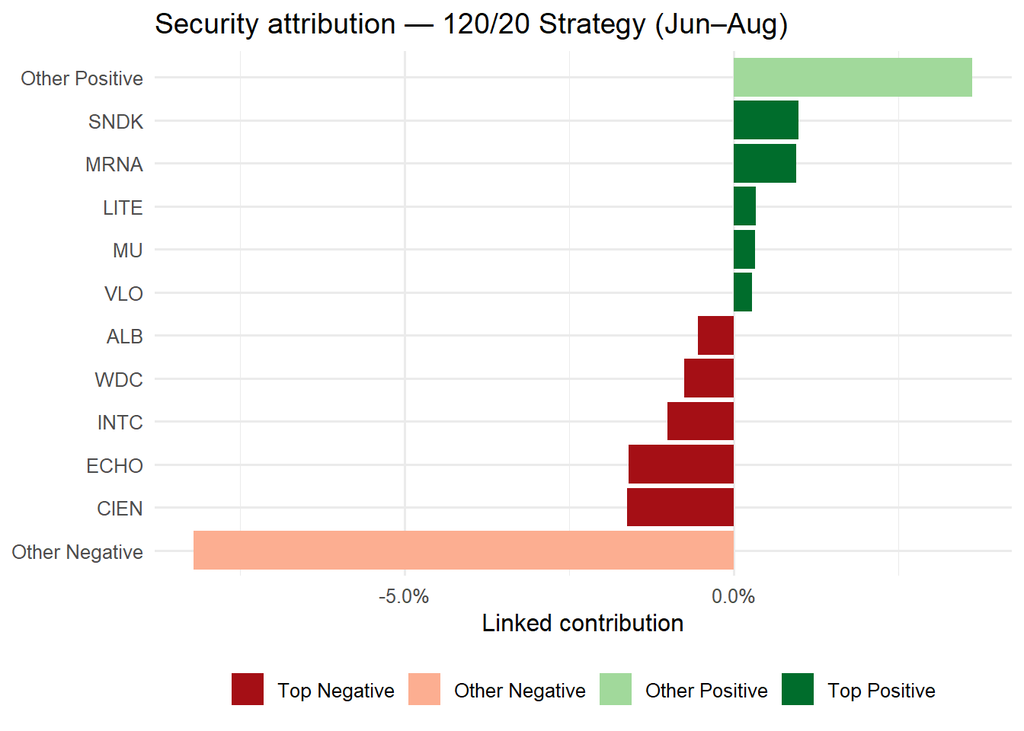

| Sleeve | Contribution |
| --- | --- |
| Long | -4.7 ppts |
| Short | -2.6 ppts |

```r
attr_tab("all", "Jun–Aug")
```

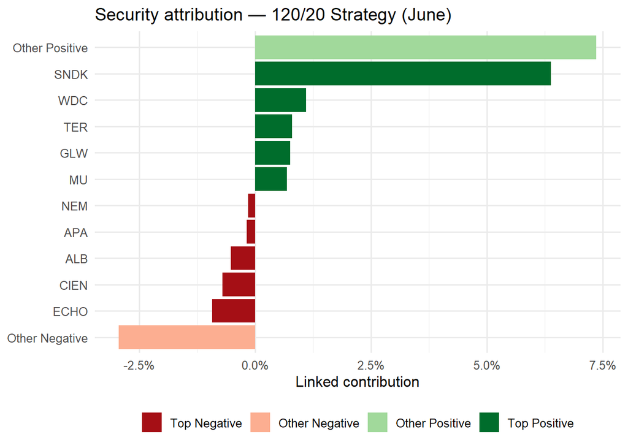

| Sleeve | Contribution |
| --- | --- |
| Long | 11.4 ppts |
| Short | 0.3 ppts |

```r
attr_tab("2026-06-01", "June")
```

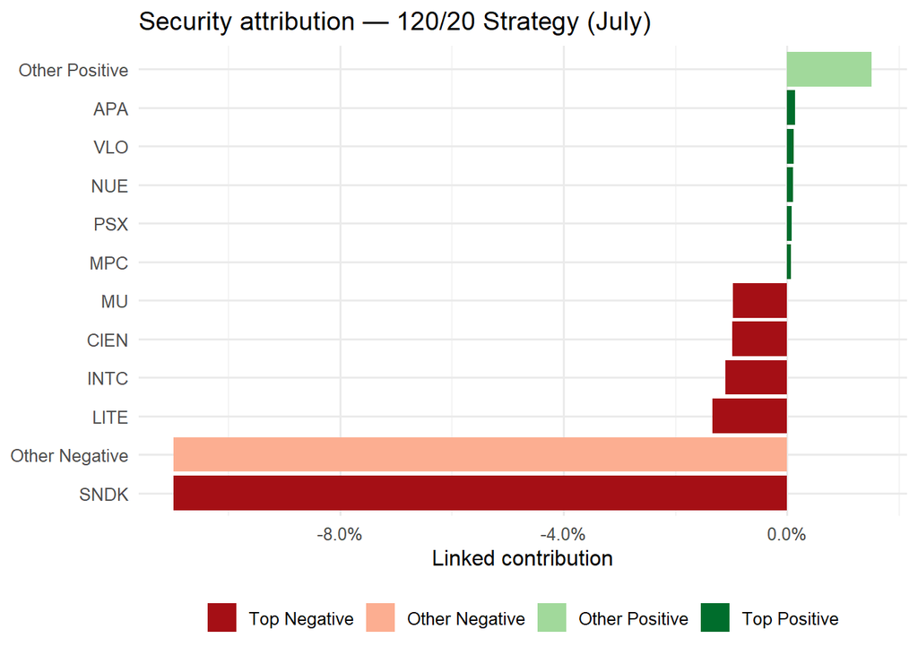

| Sleeve | Contribution |
| --- | --- |
| Long | -22.8 ppts |
| Short | -1.5 ppts |

```r
attr_tab("2026-07-01", "July")
```

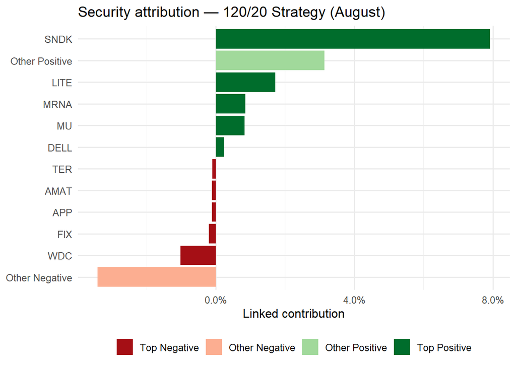

| Sleeve | Contribution |
| --- | --- |
| Long | 11.1 ppts |
| Short | -1.3 ppts |

```r
attr_tab("2026-08-01", "August")
```

**All**

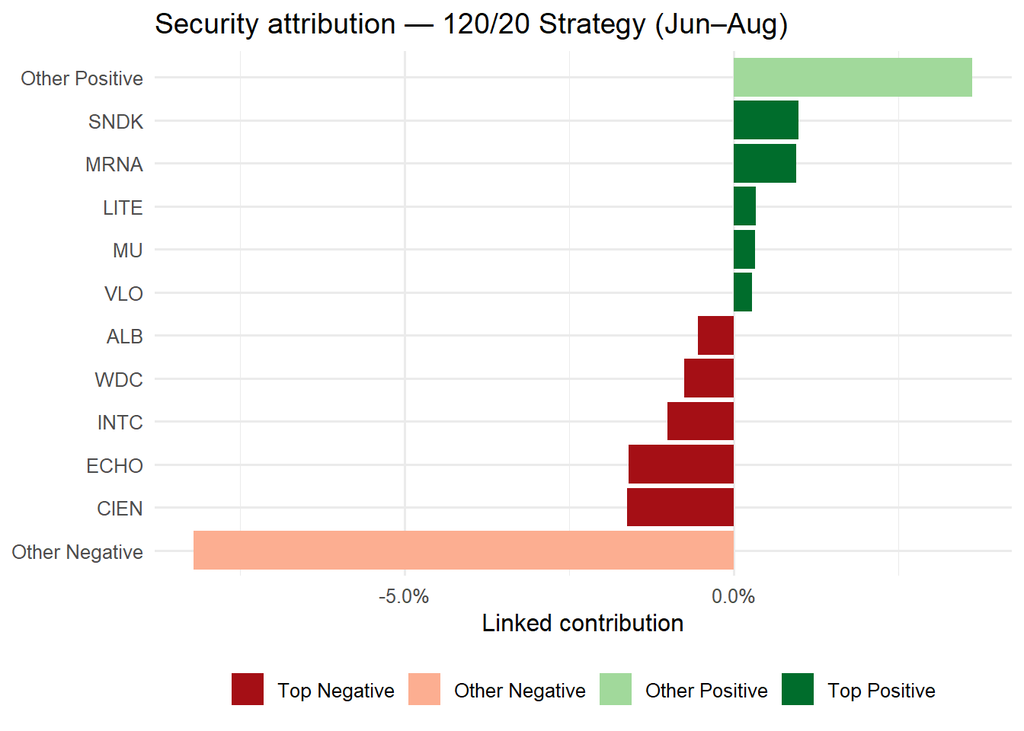

| Sleeve | Contribution |
| --- | --- |
| Long | -4.7 ppts |
| Short | -2.6 ppts |

**June**

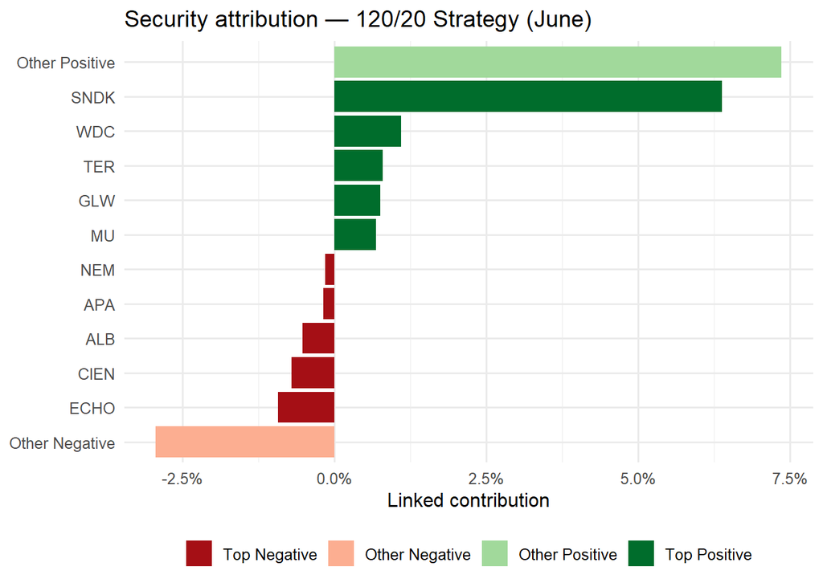

| Sleeve | Contribution |
| --- | --- |
| Long | 11.4 ppts |
| Short | 0.3 ppts |

**July**

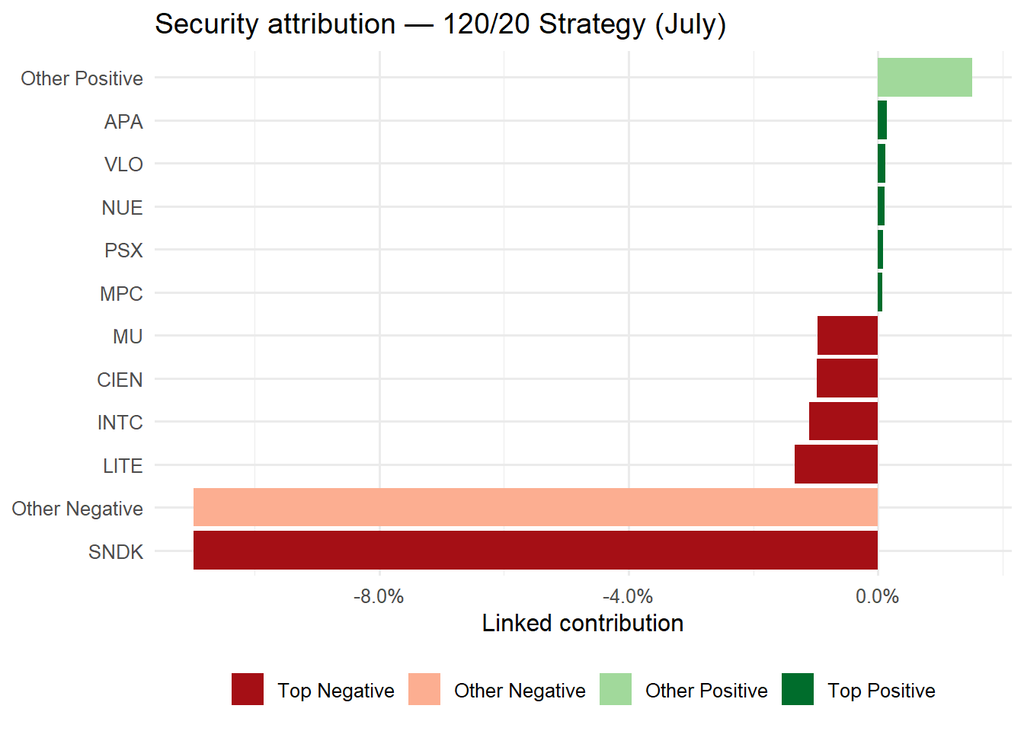

| Sleeve | Contribution |
| --- | --- |
| Long | -22.8 ppts |
| Short | -1.5 ppts |

**August**

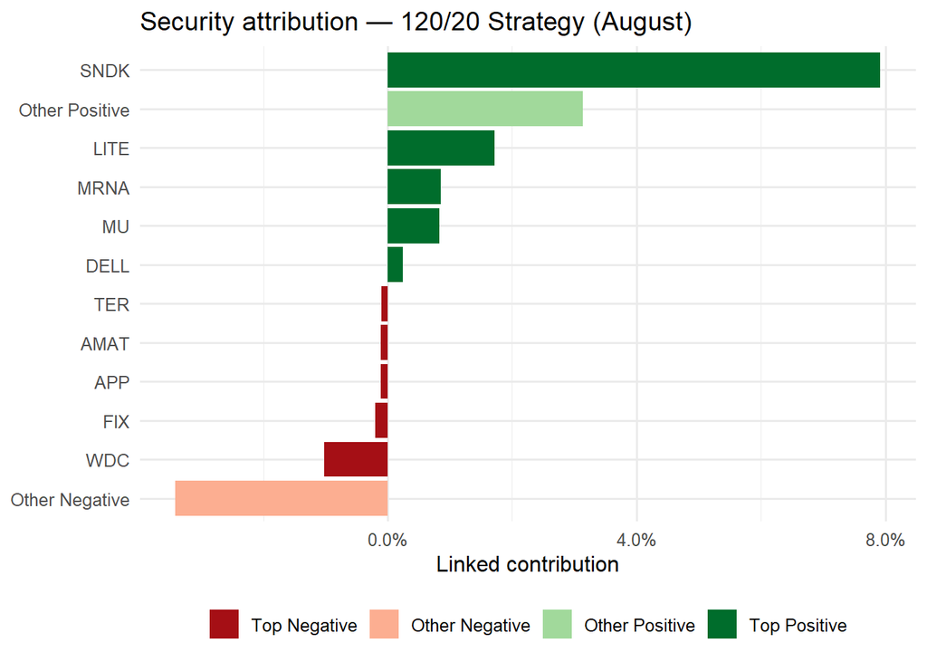

| Sleeve | Contribution |
| --- | --- |
| Long | 11.1 ppts |
| Short | -1.3 ppts |

## Drawdown

Task: Plot the underwater (drawdown) curves for the strategy versus IVV.

```r
dd <- bind_rows(
  port  |> transmute(date, drawdown, Series = settings$labels["strategy"]),
  bench |> transmute(date, drawdown = benchmark_drawdown, Series = settings$labels["benchmark"])
)
p_dd <- dd |>
  ggplot(aes(date, drawdown, color = Series)) +
  geom_line(linewidth = 0.8) +
  scale_y_continuous(labels = percent_format(accuracy = 1)) +
  scale_color_manual(values = setNames(c(strategy_color, benchmark_color),
                                       settings$labels[c("strategy", "benchmark")])) +
  labs(x = NULL, y = "Drawdown", color = NULL, title = "Underwater plot") +
  theme(legend.position = "bottom")
ggplotly(p_dd)
```

[interactive chart not shown]

## Signal Efficacy (Walk-Forward)

The single-holdout evaluation scores one month. Because the quartile signal is rebuilt at each formation, we can evaluate it across all three holdouts (Jun/Jul/Aug 2026) with the multiple-holdout engine, which loops the single-holdout evaluation over the shared evaluation dates.

Task: Re-key the continuous `panel` signal to its evaluation month, build the matching monthly-return series, and run the walk-forward evaluation. Use our signal_evaluation_multipleholdout function.

```r
signal_position_ts <- panel |>
  filter(!is.na(signal)) |>
  transmute(date = evaluation_month, ticker, signal_position = signal)

returns_ts <- monthly_returns |>
  filter(month %in% unique(panel$evaluation_month)) |>
  transmute(date = month, ticker, test_returns = monthly_return)

MultiEval <- signal_evaluation_multipleholdout(
  signal_position_ts = signal_position_ts,
  returns_ts         = returns_ts,
  Meta               = Meta,
  return_threshold   = return_threshold,
  verbose            = FALSE
)
```

Task: Display the period-by-period results.

```r
MultiEval$by_date
```

```
# A tibble: 3 × 7
  date        ic_all ic_acted hit_overall hit_acted coverage     n
  <date>       <dbl>    <dbl>       <dbl>     <dbl>    <dbl> <int>
1 2026-06-01  0.130     0.154       0.265     0.528    0.501   499
2 2026-07-01 -0.276    -0.322       0.198     0.396    0.501   499
3 2026-08-01 -0.0934   -0.106       0.206     0.412    0.501   499
```

Q: Interpret the evolution of the portfolio.

Task: Display the time-series summary (mean and SD of IC, hit rate, and coverage).

```r
MultiEval$ts_summary
```

```
# A tibble: 4 × 3
  Metric         Mean    SD
  <chr>         <dbl> <dbl>
1 IC (All)    -0.0799 0.203
2 IC (Acted)  -0.0913 0.238
3 Hit (Acted)  0.445  0.072
4 Coverage     0.501  0
```

Task: Plot the information coefficient across the holdout window.

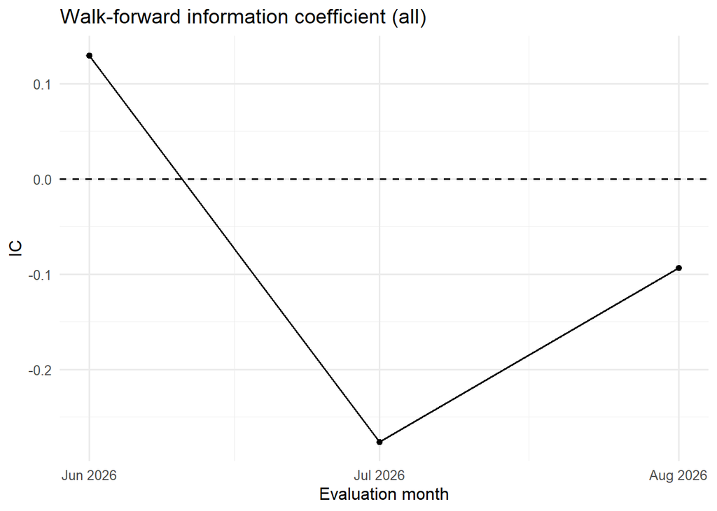

```r
MultiEval$by_date |>
  ggplot(aes(date, ic_all)) +
  geom_line() +
  geom_point() +
  geom_hline(yintercept = 0, linetype = "dashed") +
  scale_x_date(breaks = scales::breaks_width("1 month"), labels = scales::date_format("%b %Y")) +
  labs(title = "Walk-forward information coefficient (all)",
       x = "Evaluation month", y = "IC")
```

### Evaluate relative to benchmark

Task: Convert the holdout returns to excess-of-IVV returns and re-run the walk-forward evaluation.

```r
index_returns_ts <- monthly |>
  filter(asset_role == "benchmark") |>
  compute_monthly_returns() |>
  filter(month %in% unique(panel$evaluation_month)) |>
  transmute(date = month, index_return = monthly_return)

returns_ts_benchmark <- returns_ts |>
  left_join(index_returns_ts, by = "date") |>
  mutate(test_returns = test_returns - index_return) |>
  select(date, ticker, test_returns)

MultiEvalBenchmark <- signal_evaluation_multipleholdout(
  signal_position_ts = signal_position_ts,
  returns_ts         = returns_ts_benchmark,
  Meta               = Meta,
  return_threshold   = 0,
  verbose            = FALSE
)

MultiEvalBenchmark$ts_summary
```

```
# A tibble: 4 × 3
  Metric         Mean     SD
  <chr>         <dbl>  <dbl>
1 IC (All)    -0.0799 0.203
2 IC (Acted)  -0.0913 0.238
3 Hit (Acted)  0.447  0.0671
4 Coverage     0.501  0
```

Q: What can, and cannot, three holdout months tell us about this signal?

A: Averaging IC and hit rate across Jun–Aug gives a more stable read than any single month, and the spread across months (SD relative to mean) flags how unstable the signal is. But three observations is a very small sample: the walk-forward averages here are illustrative, not evidence of persistent predictive power. This mirrors the “short sample” caveat already declared for the portfolio statistics.